# 07. Dialogues on Democracy: Results 3, Effects by Baseline Conviction

Shaye

2026-10-27

Manuscript section “Intervention efficacy persists among the most entrenched believers” and Appendix D: condition x baseline interactions, GAMs, a shift-function CDF and baseline-adjusted quantile regression, the type-of-change summary, die-hard vs. non-die-hard models, ceiling-censoring robustness (Tobit and ceiling-escape models) and random-forest variable importance (a robustness comparison; the main-text variable-importance figure comes from `09_heterogeneity_forests.Rmd`). Produces `figures/fig-baseline-conviction.png`, `figures/supplement/fig-belief-change.png`, `results/models_belief_level.rds` and `results/models_ceiling.rds`.

# 1. Change relative to baseline conviction: GAMs & quantile regression

### 1.1. Interaction with baseline belief levels

```r
# Robust (HC1) inference + stars; displays "Estimate (SE)" column.

# ---- baseline interaction regression (robust p-values) ----
analyze_int <- function(dvs_post, dvs_pre, data, study) {

  # dv_post ~ ConditionFeedback * baseline + (ConditionChat if Study 1)
  formula_base <- paste(dvs_post, "~ ConditionFeedback *", dvs_pre)
  if (study == 1) formula_base <- paste(formula_base, "+ ConditionChat")
  formula <- as.formula(formula_base)

  model <- lm(formula, data = data)

  V  <- sandwich::vcovHC(model, type = "HC1")
  ct <- lmtest::coeftest(model, vcov. = V)

  tibble::tibble(
    term      = rownames(ct),
    estimate  = unname(ct[, 1]),
    std.error = unname(ct[, 2]),
    statistic = unname(ct[, 3]),
    p.value   = unname(ct[, 4]),
    outcome   = dvs_post
  )
}

# ---- run interaction models ----
reg_s1_int <- purrr::map2(dvs_post, dvs_precenter, ~ analyze_int(.x, .y, df_consp,   study = 1))
reg_s2_int <- purrr::map2(dvs_post, dvs_precenter, ~ analyze_int(.x, .y, df_consp_2, study = 2))

# ---- combine + label (uses combine_regression_results(), which keeps `Estimate (SE)` + stars) ----
regression_int <- combine_regression_results(reg_s1_int, 1) %>%
  bind_rows(combine_regression_results(reg_s2_int, 2)) %>%
  mutate(DV = dplyr::recode(DV, !!!new_labels))

# ---- display: cleanresults stargazer version ----
res_baseint_s1 <- clean_regress(
  df_consp,
  dvs = dvs_post,
  type = "linear",
  predictors = ~ ConditionFeedback + ConditionChat,
  baseline = baseline_map,
  lin = "ConditionFeedback",
  vcov_type = "HC1",
  dv_labels = new_labels
)

res_baseint_s2 <- clean_regress(
  df_consp_2,
  dvs = dvs_post,
  type = "linear",
  predictors = ~ ConditionFeedback,
  baseline = baseline_map,
  lin = "ConditionFeedback",
  vcov_type = "HC1",
  dv_labels = new_labels
)

cr_table(res_baseint_s1, style = "stargazer")
```

|  | 2020 Denialism (Main) Linear b | Claim Certainty Linear b | General Denialism Linear b | Specific Denialism Linear b | 2020 Denialism (Aggregate) Linear b | 2024 Denialism Linear b | Election Denialism (Aggregate) Linear b | Affective Polarization Linear b |
| --- | --- | --- | --- | --- | --- | --- | --- | --- |
| Intercept | 78.73*** | 85.15*** | 3.13*** | 3.49*** | 71.51*** | 3.05*** | 66.73*** | 53.16*** |
|  | (0.94) | (1.03) | (0.03) | (0.04) | (0.86) | (0.05) | (0.82) | (1.07) |
| Condition feedback |  |  |  |  |  |  |  |  |
| Adversarial dialogue (ref.) | — | — | — | — | — | — | — | — |
| Control |  |  |  |  |  |  |  |  |
| Belief & values tailored | -2.38* | -2.34 | 0.00 | -0.02 | -1.92 | 0.06 | -0.19 | 1.67 |
|  | (1.16) | (1.25) | (0.04) | (0.04) | (1.06) | (0.06) | (0.98) | (1.29) |
| Belief tailored | -3.74** | -3.78** | -0.09* | -0.03 | -2.55* | 0.07 | -1.90 | -0.67 |
|  | (1.22) | (1.31) | (0.04) | (0.04) | (1.11) | (0.06) | (1.02) | (1.33) |
| Condition chat |  |  |  |  |  |  |  |  |
| Chat (ref.) | — | — | — | — | — | — | — | — |
| Qualtrics | 1.28 | 1.18 | 0.05 | 0.05 | 1.94* | -0.03 | 1.40 | -1.00 |
|  | (0.99) | (1.08) | (0.03) | (0.04) | (0.91) | (0.05) | (0.83) | (1.09) |
| Baseline (centered) | 0.71*** | 0.65*** | 0.79*** | 0.76*** | 0.78*** | 0.66*** | 0.82*** | 0.87*** |
|  | (0.04) | (0.07) | (0.05) | (0.04) | (0.03) | (0.05) | (0.04) | (0.03) |
| Control × Baseline (centered) |  |  |  |  |  |  |  |  |
| Belief & values tailored × Baseline (centered) | 0.05 | 0.00 | 0.00 | 0.04 | -0.01 | 0.10 | 0.03 | -0.04 |
|  | (0.07) | (0.10) | (0.07) | (0.06) | (0.05) | (0.06) | (0.05) | (0.06) |
| Belief tailored × Baseline (centered) | 0.15* | -0.08 | 0.04 | 0.05 | 0.01 | 0.07 | 0.04 | 0.06 |
|  | (0.07) | (0.10) | (0.07) | (0.06) | (0.05) | (0.06) | (0.06) | (0.04) |
| Model fit |  |  |  |  |  |  |  |  |
| Observations | 1,114 | 1,115 | 1,114 | 1,114 | 1,114 | 1,114 | 1,114 | 1,113 |
| R² | 0.46 | 0.20 | 0.51 | 0.53 | 0.52 | 0.49 | 0.57 | 0.72 |
| AIC | 9416.36 | 9620.22 | 1798.48 | 2035.71 | 9222.26 | 2525.30 | 9017.24 | 9585.24 |

Note. b = unstandardized coefficient; SE = standard error. SEs and p-values use HC1 robust SEs. Standard errors in parentheses. (ref.) marks the reference category for each factor. * p < .05. ** p < .01. *** p < .001.  
Empty cells: coefficient not estimable in that model (collinear or no observations).

```r
cr_table(res_baseint_s2, style = "stargazer")
```

|  | 2020 Denialism (Main) Linear b | Claim Certainty Linear b | General Denialism Linear b | Specific Denialism Linear b | 2020 Denialism (Aggregate) Linear b | 2024 Denialism Linear b | Election Denialism (Aggregate) Linear b | Affective Polarization Linear b |
| --- | --- | --- | --- | --- | --- | --- | --- | --- |
| Intercept | 79.99*** | 86.86*** | 3.11*** | 3.41*** | 70.45*** | 2.97*** | 65.25*** | 49.96*** |
|  | (0.86) | (0.67) | (0.03) | (0.04) | (0.94) | (0.06) | (0.80) | (1.39) |
| Condition feedback |  |  |  |  |  |  |  |  |
| Control (ref.) | — | — | — | — | — | — | — | — |
| Adversarial dialogue | -2.37 | 0.60 | 0.03 | 0.02 | -0.89 | 0.09 | 0.82 | -3.84 |
|  | (1.40) | (1.12) | (0.05) | (0.06) | (1.32) | (0.08) | (1.13) | (2.13) |
| Belief & values tailored |  |  |  |  |  |  |  |  |
| Belief tailored | -3.27* | -3.93** | -0.07 | -0.11 | -3.28* | -0.08 | -2.33* | -3.47 |
|  | (1.34) | (1.33) | (0.05) | (0.06) | (1.44) | (0.08) | (1.14) | (2.12) |
| Baseline (centered) | 0.81*** | 0.75*** | 0.89*** | 0.68*** | 0.74*** | 0.59*** | 0.86*** | 0.91*** |
|  | (0.05) | (0.06) | (0.06) | (0.05) | (0.05) | (0.08) | (0.05) | (0.04) |
| Adversarial dialogue × Baseline (centered) | -0.04 | -0.13 | -0.09 | 0.11 | 0.11 | 0.12 | -0.01 | -0.05 |
|  | (0.08) | (0.10) | (0.10) | (0.07) | (0.06) | (0.10) | (0.07) | (0.06) |
| Belief & values tailored × Baseline (centered) |  |  |  |  |  |  |  |  |
| Belief tailored × Baseline (centered) | 0.04 | -0.09 | -0.03 | 0.06 | 0.02 | 0.10 | 0.00 | -0.05 |
|  | (0.09) | (0.09) | (0.08) | (0.08) | (0.08) | (0.10) | (0.07) | (0.06) |
| Model fit |  |  |  |  |  |  |  |  |
| Observations | 545 | 545 | 545 | 545 | 545 | 545 | 545 | 544 |
| R² | 0.56 | 0.41 | 0.67 | 0.51 | 0.56 | 0.44 | 0.72 | 0.71 |
| AIC | 4400.55 | 4308.48 | 679.81 | 987.64 | 4392.85 | 1281.13 | 4151.45 | 4843.75 |

Note. b = unstandardized coefficient; SE = standard error. SEs and p-values use HC1 robust SEs. Standard errors in parentheses. (ref.) marks the reference category for each factor. * p < .05. ** p < .01. *** p < .001.  
Empty cells: coefficient not estimable in that model (collinear or no observations).

```r
# Retain legacy model lists for backward compatibility with supplement.qmd
build_formula_int <- function(dv, dv_pre, study) {
  formula_base <- paste(dv, "~ ConditionFeedback *", dv_pre)
  if (study == 1) formula_base <- paste(formula_base, "+ ConditionChat")
  as.formula(formula_base)
}

fit_model_list_int <- function(dvs, dvs_pre, data, study) {
  models <- purrr::map2(dvs, dvs_pre, ~ lm(build_formula_int(.x, .y, study), data = data))
  names(models) <- dvs
  models
}

models_s1_baseint <- fit_model_list_int(dvs_post, dvs_precenter, df_consp, study = 1)
models_s2_baseint <- fit_model_list_int(dvs_post, dvs_precenter, df_consp_2, study = 2)

if (FALSE) {
regression_int %>%
  kable(caption = "Regression Results: Interaction with Baseline Beliefs",
        align = "l") %>%
  kable_classic(full_width = FALSE, html_font = "Times New Roman") %>%
  kable_styling(bootstrap_options = c("striped", "hover", "responsive"),
                font_size = 12, fixed_thead = TRUE) %>%
  collapse_rows(1:2, row_group_label_position = "stack", valign = "top")
} # end disabled kable block
```

### 1.2. GAMs

```r
tab_model(m.s1.er0_gam, m.s1.sure_gam,
          auto.label = T,
          p.style = "stars",
          show.ci = F,  vcov.args = list(type = "HC1"),
          show.se = F,
          show.stat = T,
          dv.labels = c("1: 2020 Denialism (Main)", "2: Claim Certainty"),
          title = "GAMs by Outcome - Study 1")
```

GAMs by Outcome - Study 1

1: 2020 Denialism (Main)

2: Claim Certainty

Predictors

Estimates

Statistic

Estimates

Statistic

(Intercept)

79.32 ***

93.70

85.65 ***

93.90

Condition Feedback:  
Belief&Values-Tailored

-2.34

-1.95

-2.32

-1.80

Condition Feedback:  
Belief-Tailored

-3.65 **

-3.00

-3.52 **

-2.68

s(ER0Norm_Pre_center)

NA ***

52.13

s(ER0Norm_Pre_center):ConditionFeedbackAdversarial Dialogue

NA

1.81

s(ER0Norm_Pre_center):ConditionFeedbackBelief & Values-Tailored

NA

2.17

s(ER0Norm_Pre_center):ConditionFeedbackBelief-Tailored

NA

0.40

s(Sureness_Pre_center)

NA ***

23.91

s(Sureness_Pre_center):ConditionFeedbackAdversarial Dialogue

NA

0.72

s(Sureness_Pre_center):ConditionFeedbackBelief & Values-Tailored

NA

1.17

s(Sureness_Pre_center):ConditionFeedbackBelief-Tailored

NA

0.01

Observations

1114

1115

R<sup>2</sup>

0.453

0.220

- p<0.05 ** p<0.01 *** p<0.001

```r
tab_model(m.s2.er0_gam, m.s2.sure_gam,
          auto.label = T,
          p.style = "stars",
          show.ci = F,  vcov.args = list(type = "HC1"),
          show.se = F,
          show.stat = T,
          dv.labels = c("1: 2020 Denialism (Main)", "2: Claim Certainty"),
          title = "GAMs by Outcome - Study 2")
```

GAMs by Outcome - Study 2

1: 2020 Denialism (Main)

2: Claim Certainty

Predictors

Estimates

Statistic

Estimates

Statistic

(Intercept)

79.99 ***

80.04

86.94 ***

96.75

Condition Feedback:  
Adversarial Dialogue

-2.52

-1.73

0.27

0.21

Condition Feedback:  
Belief-Tailored

-3.27 *

-2.33

-3.98 **

-3.16

s(ER0Norm_Pre_center)

NA ***

236.22

s(ER0Norm_Pre_center):ConditionFeedbackControl

NA

0.29

s(ER0Norm_Pre_center):ConditionFeedbackAdversarial Dialogue

NA

1.16

s(ER0Norm_Pre_center):ConditionFeedbackBelief-Tailored

NA

0.02

s(Sureness_Pre_center)

NA ***

51.40

s(Sureness_Pre_center):ConditionFeedbackControl

NA

0.00

s(Sureness_Pre_center):ConditionFeedbackAdversarial Dialogue

NA *

2.52

s(Sureness_Pre_center):ConditionFeedbackBelief-Tailored

NA

0.85

Observations

545

545

R<sup>2</sup>

0.554

0.438

- p<0.05 ** p<0.01 *** p<0.001

```r
tab_model(m.s1.er0_gam, m.s1.sure_gam,
          m.s1.er1_gam, m.s1.er2_gam,
          m.s1.er2020_gam, m.s1.er2024_gam,
          m.s1.eragg_gam, m.s1.ap_gam,
          auto.label = T,
          p.style = "stars",
          show.ci = F,  vcov.args = list(type = "HC1"),
          show.se = F,
          show.stat = T,
          dv.labels = c("1: 2020 Denialism (Main)", "2: Claim Certainty",
                        "3: General Denialism", "4: Specific Denialism",
                        "5: 2020 Denialism (Aggregate)", "6: 2024 Denialism",
                        "7: Aggregate Denialism","8: Affective Polarization"),
          title = "GAMs by Outcome - Study 1")
```

GAMs by Outcome - Study 1

1: 2020 Denialism (Main)

2: Claim Certainty

3: General Denialism

4: Specific Denialism

5: 2020 Denialism (Aggregate)

6: 2024 Denialism

7: Aggregate Denialism

8: Affective Polarization

Predictors

Estimates

Statistic

Estimates

Statistic

Estimates

Statistic

Estimates

Statistic

Estimates

Statistic

Estimates

Statistic

Estimates

Statistic

Estimates

Statistic

(Intercept)

79.32 ***

93.70

85.65 ***

93.90

71.91 ***

79.43

62.91 ***

82.41

3.07 ***

63.38

3.04 ***

79.31

67.33 ***

95.19

52.67 ***

59.99

Condition Feedback:  
Belief&Values-Tailored

-2.34

-1.95

-2.32

-1.80

-0.18

-0.14

-0.69

-0.64

-0.02

-0.33

0.07

1.23

-0.10

-0.10

1.43

1.15

Condition Feedback:  
Belief-Tailored

-3.65 **

-3.00

-3.52 **

-2.68

-2.65 *

-2.02

-0.56

-0.51

0.05

0.73

0.07

1.35

-1.74

-1.70

-0.65

-0.51

s(ER0Norm_Pre_center)

NA ***

52.13

s(ER0Norm_Pre_center):ConditionFeedbackAdversarial Dialogue

NA

1.81

s(ER0Norm_Pre_center):ConditionFeedbackBelief & Values-Tailored

NA

2.17

s(ER0Norm_Pre_center):ConditionFeedbackBelief-Tailored

NA

0.40

s(Sureness_Pre_center)

NA ***

23.91

s(Sureness_Pre_center):ConditionFeedbackAdversarial Dialogue

NA

0.72

s(Sureness_Pre_center):ConditionFeedbackBelief & Values-Tailored

NA

1.17

s(Sureness_Pre_center):ConditionFeedbackBelief-Tailored

NA

0.01

s(ER1_Pre_center)

NA ***

24.07

s(ER1_Pre_center):ConditionFeedbackAdversarial Dialogue

NA

0.04

s(ER1_Pre_center):ConditionFeedbackBelief & Values-Tailored

NA

1.01

s(ER1_Pre_center):ConditionFeedbackBelief-Tailored

NA

0.04

s(ER2_Pre_center)

NA ***

413.83

s(ER2_Pre_center):ConditionFeedbackAdversarial Dialogue

NA

0.93

s(ER2_Pre_center):ConditionFeedbackBelief & Values-Tailored

NA **

3.61

s(ER2_Pre_center):ConditionFeedbackBelief-Tailored

NA

0.00

s(ER2020_Pre)

NA ***

91.41

s(ER2020_Pre):ConditionFeedbackAdversarial Dialogue

NA

2.46

s(ER2020_Pre):ConditionFeedbackBelief & Values-Tailored

NA

0.06

s(ER2020_Pre):ConditionFeedbackBelief-Tailored

NA

0.03

s(ER2024_Pre)

NA ***

35.59

s(ER2024_Pre):ConditionFeedbackAdversarial Dialogue

NA

1.58

s(ER2024_Pre):ConditionFeedbackBelief & Values-Tailored

NA

0.54

s(ER2024_Pre):ConditionFeedbackBelief-Tailored

NA

0.25

s(ERNorm_Pre_center)

NA ***

390.43

s(ERNorm_Pre_center):ConditionFeedbackAdversarial Dialogue

NA

1.23

s(ERNorm_Pre_center):ConditionFeedbackBelief & Values-Tailored

NA

0.01

s(ERNorm_Pre_center):ConditionFeedbackBelief-Tailored

NA

0.00

s(AffPol_Pre_center)

NA ***

204.10

s(AffPol_Pre_center):ConditionFeedbackAdversarial Dialogue

NA

0.05

s(AffPol_Pre_center):ConditionFeedbackBelief & Values-Tailored

NA ***

6.19

s(AffPol_Pre_center):ConditionFeedbackBelief-Tailored

NA

2.07

Observations

1114

1115

1114

1114

1114

1114

1114

1113

R<sup>2</sup>

0.453

0.220

0.525

0.538

0.181

0.491

0.564

0.747

- p<0.05 ** p<0.01 *** p<0.001

```r
tab_model(m.s2.er0_gam, m.s2.sure_gam,
          m.s2.er1_gam, m.s2.er2_gam,
          m.s2.er2020_gam, m.s2.er2024_gam,
          m.s2.eragg_gam, m.s2.ap_gam,
          auto.label = T,
          p.style = "stars",
          show.ci = F,  vcov.args = list(type = "HC1"),
          show.se = F,
          show.stat = T,
          dv.labels = c("1: 2020 Denialism (Main)", "2: Claim Certainty",
                        "3: General Denialism", "4: Specific Denialism",
                        "5: 2020 Denialism (Aggregate)", "6: 2024 Denialism",
                        "7: Aggregate Denialism","8: Affective Polarization"),
          title = "GAMs by Outcome - Study 2")
```

GAMs by Outcome - Study 2

1: 2020 Denialism (Main)

2: Claim Certainty

3: General Denialism

4: Specific Denialism

5: 2020 Denialism (Aggregate)

6: 2024 Denialism

7: Aggregate Denialism

8: Affective Polarization

Predictors

Estimates

Statistic

Estimates

Statistic

Estimates

Statistic

Estimates

Statistic

Estimates

Statistic

Estimates

Statistic

Estimates

Statistic

Estimates

Statistic

(Intercept)

79.99 ***

80.04

86.94 ***

96.75

70.33 ***

64.81

60.20 ***

55.77

2.96 ***

42.77

2.97 ***

51.98

65.25 ***

82.40

49.93 ***

33.30

Condition Feedback:  
Adversarial Dialogue

-2.52

-1.73

0.27

0.21

0.90

0.57

0.45

0.29

0.19

1.84

0.09

1.03

0.74

0.64

-3.79

-1.74

Condition Feedback:  
Belief-Tailored

-3.27 *

-2.33

-3.98 **

-3.16

-2.21

-1.45

-2.51

-1.66

-0.12

-1.25

-0.08

-0.97

-2.33 *

-2.10

-3.42

-1.63

s(ER0Norm_Pre_center)

NA ***

236.22

s(ER0Norm_Pre_center):ConditionFeedbackControl

NA

0.29

s(ER0Norm_Pre_center):ConditionFeedbackAdversarial Dialogue

NA

1.16

s(ER0Norm_Pre_center):ConditionFeedbackBelief-Tailored

NA

0.02

s(Sureness_Pre_center)

NA ***

51.40

s(Sureness_Pre_center):ConditionFeedbackControl

NA

0.00

s(Sureness_Pre_center):ConditionFeedbackAdversarial Dialogue

NA *

2.52

s(Sureness_Pre_center):ConditionFeedbackBelief-Tailored

NA

0.85

s(ER1_Pre_center)

NA *

5.22

s(ER1_Pre_center):ConditionFeedbackControl

NA

1.83

s(ER1_Pre_center):ConditionFeedbackAdversarial Dialogue

NA *

4.98

s(ER1_Pre_center):ConditionFeedbackBelief-Tailored

NA

2.36

s(ER2_Pre_center)

NA ***

39.87

s(ER2_Pre_center):ConditionFeedbackControl

NA

0.11

s(ER2_Pre_center):ConditionFeedbackAdversarial Dialogue

NA

1.08

s(ER2_Pre_center):ConditionFeedbackBelief-Tailored

NA

0.73

s(ER2020_Pre)

NA *

5.45

s(ER2020_Pre):ConditionFeedbackControl

NA

0.63

s(ER2020_Pre):ConditionFeedbackAdversarial Dialogue

NA

1.52

s(ER2020_Pre):ConditionFeedbackBelief-Tailored

NA *

3.17

s(ER2024_Pre)

NA ***

73.39

s(ER2024_Pre):ConditionFeedbackControl

NA

1.36

s(ER2024_Pre):ConditionFeedbackAdversarial Dialogue

NA

0.01

s(ER2024_Pre):ConditionFeedbackBelief-Tailored

NA

0.03

s(ERNorm_Pre_center)

NA ***

466.08

s(ERNorm_Pre_center):ConditionFeedbackControl

NA

0.04

s(ERNorm_Pre_center):ConditionFeedbackAdversarial Dialogue

NA

2.08

s(ERNorm_Pre_center):ConditionFeedbackBelief-Tailored

NA

0.00

s(AffPol_Pre_center)

NA ***

79.42

s(AffPol_Pre_center):ConditionFeedbackControl

NA

0.82

s(AffPol_Pre_center):ConditionFeedbackAdversarial Dialogue

NA

0.01

s(AffPol_Pre_center):ConditionFeedbackBelief-Tailored

NA

0.00

Observations

545

545

545

545

545

545

545

544

R<sup>2</sup>

0.554

0.438

0.677

0.523

0.177

0.439

0.716

0.719

- p<0.05 ** p<0.01 *** p<0.001

#### Figure: Change by baseline conviction (`fig-baseline-conviction`)

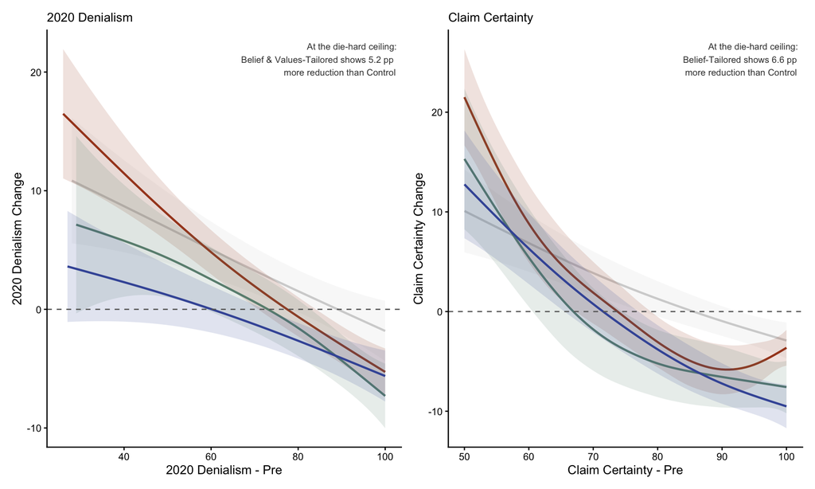

```r
df_both2 <- df_both %>% filter(!(is.na(ConditionFeedback)))
control_label <- "Control"

# predicted change at the die-hard ceiling (baseline = 100), per condition, from each panel's own GAM -- quantifies the regression-to-the-mean
gam_ceiling_delta <- function(data, x_var, y_var) {
  fits <- data %>%
    filter(!is.na(.data[[x_var]]), !is.na(.data[[y_var]])) %>%
    group_by(ConditionFeedback) %>%
    group_modify(~ {
      fit <- mgcv::gam(reformulate(paste0("s(", x_var, ", bs = \"cs\")"), response = y_var), data = .x)
      gam_pred <- predict(fit, newdata = setNames(data.frame(100), x_var), se.fit = TRUE)
      tibble(pred = as.numeric(gam_pred$fit), se = as.numeric(gam_pred$se.fit))
    }) %>%
    ungroup()
  ctl <- fits %>% filter(ConditionFeedback == control_label)
  fits %>%
    filter(ConditionFeedback != control_label) %>%
    mutate(delta = ctl$pred - pred, delta_se = sqrt(se^2 + ctl$se^2)) %>%
    slice_max(delta, n = 1) %>%
    mutate(label = sprintf("At the die-hard ceiling:\n%s shows %.1f pp\nmore reduction than Control",
                            ConditionFeedback, delta, delta_se))
}

ann_gama <- gam_ceiling_delta(df_both2, "ER0Norm_Pre", "ER0_Diff")
ann_gamb <- gam_ceiling_delta(df_both2, "Sureness_Pre_1", "Sureness_Diff")

# shared style for the small in-panel stat callouts, kept consistent across all three panels
ann_style <- list(size = 2.8, color = "gray25", fontface = "plain")

fig.gama <- ggplot(df_both2, aes(x = ER0Norm_Pre, y = ER0_Diff, color = ConditionFeedback, fill = ConditionFeedback)) +
  #geom_jitter(width = 0.3, height = 0.3, alpha = 0.1, size = 1) +
  geom_smooth(method = "gam", alpha = .15, linewidth = 0.9) +
  geom_hline(yintercept = 0, linetype = "dashed", color = "gray40") +
  #geom_vline(xintercept = 100, linetype = "dotted", color = "gray50") +
  geom_text(data = ann_gama, aes(label = label), x = Inf, y = Inf, hjust = 1.05, vjust = 1.4,
            inherit.aes = FALSE, size = ann_style$size, color = ann_style$color, fontface = ann_style$fontface) +
  labs(x = "2020 Denialism - Pre", y = "2020 Denialism Change",
       subtitle = "2020 Denialism") +
  theme_classic() +
  scale_color_manual(values = condition_colors) +
  scale_fill_manual(values = condition_colors) +
  theme(legend.position = "none") #+
  #ylim(c(-50,50))

fig.gamb <- ggplot(df_both2, aes(x = Sureness_Pre_1, y = Sureness_Diff, color = ConditionFeedback, fill = ConditionFeedback)) +
  #geom_jitter(width = 0.3, height = 0.3, alpha = 0.1, size = 1) +
  geom_smooth(method = "gam", alpha = .15, linewidth = 0.9) +
  geom_hline(yintercept = 0, linetype = "dashed", color = "gray40") +
  #geom_vline(xintercept = 100, linetype = "dotted", color = "gray50") +
  geom_text(data = ann_gamb, aes(label = label), x = Inf, y = Inf, hjust = 1.05, vjust = 1.4,
            inherit.aes = FALSE, size = ann_style$size, color = ann_style$color, fontface = ann_style$fontface) +
  labs(x = "Claim Certainty - Pre", y = "Claim Certainty Change",
       subtitle = "Claim Certainty") +
  theme_classic() +
  scale_color_manual(values = condition_colors) +
  scale_fill_manual(values = condition_colors) +
  theme(legend.position = "none") #+
  #ylim(c(-50,50))


#fig c - shift function: quantile-of-change difference vs. control, per outcome
# (replaces the raw CDF - shift function comparing quantiles of the condition's distribution directly against control's, so a departure from 0 reflects a real difference, not just shape.)
df_cdf_long <- df_both %>%
  filter(!is.na(ConditionFeedback)) %>%
  pivot_longer(cols = c(ER0_Diff, Sureness_Diff), names_to = "Outcome", values_to = "Value") %>%
  mutate(Outcome = dplyr::recode(Outcome,
                                  ER0_Diff = "2020 Denialism",
                                  Sureness_Diff = "Claim Certainty"),
         ConditionFeedback = as.character(ConditionFeedback)) %>%
  filter(!is.na(Value))

shift_qs <- seq(.1, .9, .1)
shift_R <- 2000

shift_function <- function(ctrl, trt, qs, R) {
  q_ctrl <- quantile(ctrl, probs = qs, type = 6)
  q_trt  <- quantile(trt, probs = qs, type = 6)
  diff <- q_trt - q_ctrl
  boot <- replicate(R, {
    cb <- sample(ctrl, length(ctrl), replace = TRUE)
    tb <- sample(trt, length(trt), replace = TRUE)
    quantile(tb, probs = qs, type = 6) - quantile(cb, probs = qs, type = 6)
  })
  tibble(q = qs, diff = diff,
         ci_lo = apply(boot, 1, quantile, 0.025),
         ci_hi = apply(boot, 1, quantile, 0.975))
}

shift_results <- df_cdf_long %>%
  group_by(Outcome) %>%
  group_modify(~ {
    ctrl_vals <- .x$Value[.x$ConditionFeedback == control_label]
    active_lvls <- setdiff(unique(.x$ConditionFeedback), control_label)
    purrr::map_dfr(active_lvls, function(lvl) {
      shift_function(ctrl_vals, .x$Value[.x$ConditionFeedback == lvl], shift_qs, shift_R) %>%
        mutate(ConditionFeedback = lvl)
    })
  }) %>%
  ungroup()

fig.cdf <- ggplot(shift_results, aes(x = q, y = diff, color = ConditionFeedback, fill = ConditionFeedback)) +
  geom_hline(yintercept = 0, linetype = "dashed", color = "gray40") +
  geom_ribbon(aes(ymin = ci_lo, ymax = ci_hi), alpha = 0.15, color = NA) +
  geom_line(linewidth = 0.9) +
  geom_point(size = 2) +
  facet_wrap(~Outcome) +
  scale_x_continuous(breaks = shift_qs, labels = scales::percent) +
  scale_color_manual(values = condition_colors, name = "Condition") +
  scale_fill_manual(values = condition_colors, name = "Condition") +
  labs(
    x = "Quantile of the change-score distribution",
    y = "Condition - Control difference"
  ) +
  theme_classic() +
  theme(legend.position = "bottom", legend.title = element_blank())

(fig.gama | fig.gamb)
```

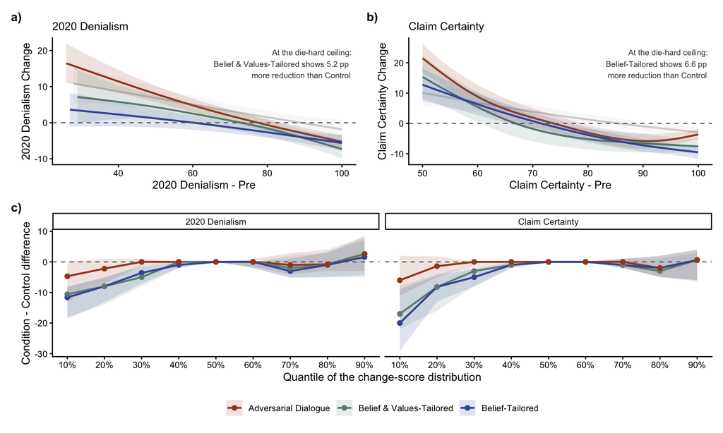

```r
fig2 <- (fig.gama | fig.gamb) / fig.cdf +
  plot_annotation(tag_levels = "a", tag_suffix = ")") &
  theme(plot.tag = element_text(size = 12, face = "bold"))
fig2
```

```r
ggsave("figures/fig-baseline-conviction.png", fig2, width = 8, height = 8, dpi = 600,create.dir = TRUE)
```

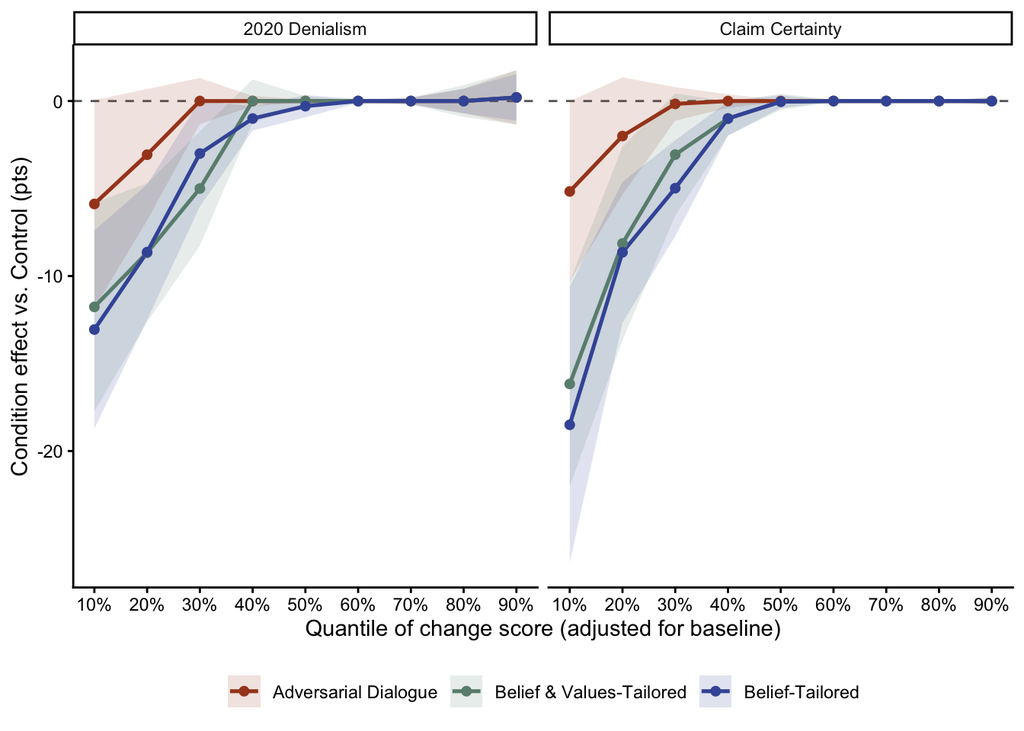

```r
# supplement Fig D1: baseline-adjusted quantile regression - condition effect vs. control
# at each quantile of the change score, controlling for baseline (nets out both regression-
# to-the-mean AND distribution shape in one model; see fig.cdf above for the unadjusted version)
pacman::p_load(quantreg)

df_both_qr <- df_both2
df_both_qr$ConditionFeedback <- relevel(factor(df_both_qr$ConditionFeedback), ref = control_label)

qr_taus <- seq(.1, .9, .1)

run_qr <- function(data, x_var, y_var, outcome_label) {
  data <- data %>% filter(!is.na(.data[[x_var]]), !is.na(.data[[y_var]]))
  form <- reformulate(c(x_var, "ConditionFeedback"), response = y_var)
  fit <- quantreg::rq(form, tau = qr_taus, data = data)
  s <- summary(fit, se = "boot", R = 500)
  purrr::map2_dfr(s, qr_taus, function(tau_summary, tau_val) {
    co <- tau_summary$coefficients
    rows <- grep("^ConditionFeedback", rownames(co))
    tibble(
      ConditionFeedback = sub("^ConditionFeedback", "", rownames(co)[rows]),
      tau = tau_val,
      estimate = co[rows, "Value"],
      se = co[rows, "Std. Error"]
    )
  }) %>%
    mutate(ci_lo = estimate - 1.96 * se, ci_hi = estimate + 1.96 * se, Outcome = outcome_label)
}

qr_results <- bind_rows(
  run_qr(df_both_qr, "ER0Norm_Pre", "ER0_Diff", "2020 Denialism"),
  run_qr(df_both_qr, "Sureness_Pre_1", "Sureness_Diff", "Claim Certainty")
)

fig.d1 <- ggplot(qr_results, aes(x = tau, y = estimate, color = ConditionFeedback, fill = ConditionFeedback)) +
  geom_hline(yintercept = 0, linetype = "dashed", color = "gray40") +
  geom_ribbon(aes(ymin = ci_lo, ymax = ci_hi), alpha = 0.15, color = NA) +
  geom_line(linewidth = 0.9) +
  geom_point(size = 1.8) +
  facet_wrap(~Outcome) +
  scale_x_continuous(breaks = qr_taus, labels = scales::percent) +
  scale_color_manual(values = condition_colors, name = "Condition") +
  scale_fill_manual(values = condition_colors, name = "Condition") +
  labs(
    x = "Quantile of change score (adjusted for baseline)",
    y = "Condition effect vs. Control (pts)"
  ) +
  theme_classic() +
  theme(legend.position = "bottom", legend.title = element_blank())

fig.d1
```

```r
ggsave("figures/supplement/fig-belief-change.png", fig.d1, width = 8, height = 5, dpi = 600, create.dir = TRUE)
```

### 1.3. Type of change summary

```r
summary(df_both$CCDieHard)*100
```

```
##    Min. 1st Qu.  Median    Mean 3rd Qu.    Max.
##    0.00    0.00    0.00   33.06  100.00  100.00
```

```r
summary(df_both$Den2020DieHard)*100
```

```
##    Min. 1st Qu.  Median    Mean 3rd Qu.    Max.
##    0.00    0.00    0.00   23.43    0.00  100.00
```

```r
prop.table(table(df_both$CCChangeType))*100
```

```
##
## Decrease Increase     Same
## 37.95181 29.39759 32.65060
```

```r
prop.change <- prop.table(table(df_both$CCChangeType, df_both$ConditionFeedback), margin = 2) * 100
prop.change
```

```
##
##             Control Adversarial Dialogue Belief & Values-Tailored
##   Decrease 31.35135             34.30657                 41.42480
##   Increase 31.89189             30.29197                 27.70449
##   Same     36.75676             35.40146                 30.87071
##
##            Belief-Tailored
##   Decrease        41.42336
##   Increase        28.83212
##   Same            29.74453
```

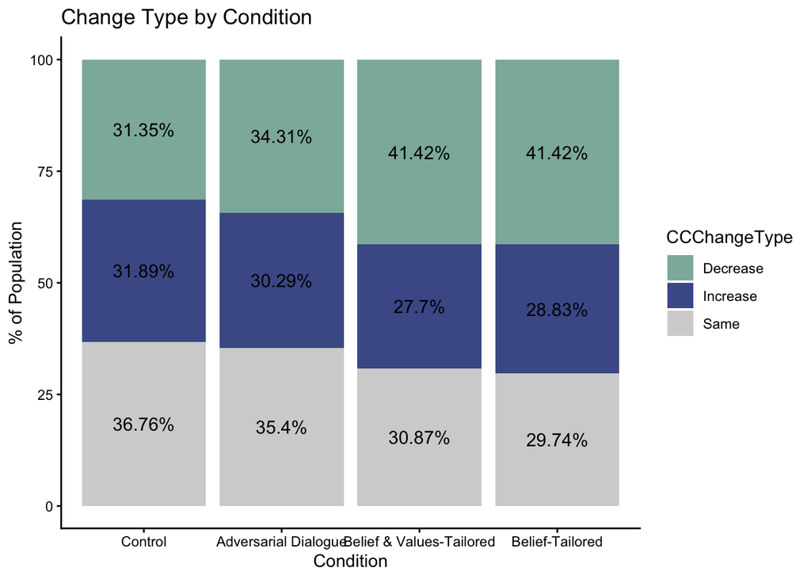

```r
#chisq.test(prop.change)

contingency_df <- as.data.frame(prop.change)
colnames(contingency_df) <- c("CCChangeType", "ConditionFeedback", "Percent")

#supplement fig----
ggplot(contingency_df, aes(x = ConditionFeedback, y = Percent, fill = CCChangeType)) +
  geom_bar(stat = "identity") +
  labs(x = "Condition", y = "% of Population", title = "Change Type by Condition") +
  theme_classic() +
  scale_fill_manual(values = c("Decrease" = "#8CB6A9", "Same"  = "lightgray", "Increase" = "#4A5C96")) +
  geom_text(aes(label = paste0(round(Percent, 2), "%")),
            position = position_stack(vjust = 0.5), size = 4, color = "black")
```

```r
summary(df_both$CCDieHardNoChange)
```

```
##    Min. 1st Qu.  Median    Mean 3rd Qu.    Max.    NA's
##  0.0000  0.0000  0.0000  0.2246  0.0000  1.0000      49
```

```r
summary(df_both$Den2020DieHardNoChange)
```

```
##    Min. 1st Qu.  Median    Mean 3rd Qu.    Max.    NA's
##  0.0000  0.0000  0.0000  0.1535  0.0000  1.0000      37
```

```r
# Run the Chi-square test
report(chisq.test(table(df_both$AnyChange, df_both$ConditionFeedback)))
```

```
## Effect sizes were labelled following Funder's (2019) recommendations.
##
## The Pearson's Chi-squared test of independence between and suggests that the
## effect is statistically not significant, and very small (chi2 = 7.44, p =
## 0.059; Adjusted Cramer's v = 0.05, 95% CI [0.00, 1.00])
```

```r
summary(df_both$ConditionFeedback)
```

```
##                  Control     Adversarial Dialogue Belief & Values-Tailored
##                      217                      590                      419
##          Belief-Tailored                     NA's
##                      619                        3
```

```r
table(df_both$AnyChange)
```

```
##
##    0    1
##  423 1236
```

```r
#74% had change in any denialism score
prop.table(table(df_both$AnyChange, df_both$ConditionFeedback), margin = 2) * 100
```

```
##
##      Control Adversarial Dialogue Belief & Values-Tailored Belief-Tailored
##   0 31.89189             27.18978                 23.74670        22.85192
##   1 68.10811             72.81022                 76.25330        77.14808
```

```r
#some sig diffs
res_anychange <- clean_regress(
  df_both,
  dvs = "AnyChange",
  type = "logistic",
  predictors = ~ ConditionFeedback,
  dv_labels = c(AnyChange = "Any Belief Change")
)
cr_table(res_anychange, style = "stargazer")
```

|  | Any Belief Change Logistic OR |
| --- | --- |
| Intercept | 2.14*** |
|  | (0.34) |
| Condition feedback |  |
| Control (ref.) | — |
| Adversarial dialogue | 1.25 |
|  | (0.23) |
| Belief & values tailored | 1.50* |
|  | (0.30) |
| Belief tailored | 1.58* |
|  | (0.30) |
| Model fit |  |
| Observations | 1,659 |
| Tjur R² | 0.00 |
| AIC | 1884.45 |

Note. OR = odds ratio; SE = standard error. SEs and p-values use HC1 robust SEs. Standard errors in parentheses (delta-method SEs for ratios). (ref.) marks the reference category for each factor. * p < .05. ** p < .01. *** p < .001.

### 1.4. Die-hards vs. non-die-hards

```r
# ---- Die-hard models (levels) ----
res_dh_s1 <- clean_regress(
  df_consp %>% dplyr::filter(CCDieHard == 1),
  dvs = dvs_post,
  type = "linear",
  predictors = ~ ConditionFeedback + ConditionChat,
  baseline = baseline_map,
  vcov_type = "HC1",
  dv_labels = new_labels
)

res_dh_s2 <- clean_regress(
  df_consp_2 %>% dplyr::filter(CCDieHard == 1),
  dvs = dvs_post,
  type = "linear",
  predictors = ~ ConditionFeedback,
  baseline = baseline_map,
  vcov_type = "HC1",
  dv_labels = new_labels
)

cr_table(res_dh_s1, style = "stargazer")
```

|  | 2020 Denialism (Main) Linear b | Claim Certainty Linear b | General Denialism Linear b | Specific Denialism Linear b | 2020 Denialism (Aggregate) Linear b | 2024 Denialism Linear b | Election Denialism (Aggregate) Linear b | Affective Polarization Linear b |
| --- | --- | --- | --- | --- | --- | --- | --- | --- |
| Intercept | 89.10*** | 96.61*** | 3.42*** | 3.81*** | 80.45*** | 3.33*** | 75.37*** | 63.92*** |
|  | (1.24) | (1.25) | (0.05) | (0.06) | (1.42) | (0.07) | (1.28) | (1.49) |
| Condition feedback |  |  |  |  |  |  |  |  |
| Adversarial dialogue (ref.) | — | — | — | — | — | — | — | — |
| Control |  |  |  |  |  |  |  |  |
| Belief & values tailored | -3.47* | -4.51** | 0.00 | -0.10 | -3.34* | -0.03 | -1.05 | 2.87 |
|  | (1.53) | (1.56) | (0.06) | (0.07) | (1.69) | (0.09) | (1.59) | (2.39) |
| Belief tailored | -4.16* | -6.10** | 0.00 | -0.04 | -3.38 | 0.10 | -0.42 | 0.50 |
|  | (2.07) | (2.08) | (0.06) | (0.08) | (2.09) | (0.10) | (1.79) | (2.30) |
| Condition chat |  |  |  |  |  |  |  |  |
| Chat (ref.) | — | — | — | — | — | — | — | — |
| Qualtrics | -0.71 | 0.80 | -0.01 | 0.10 | 2.91 | -0.07 | 1.06 | -3.41 |
|  | (1.51) | (1.56) | (0.05) | (0.06) | (1.58) | (0.08) | (1.39) | (2.01) |
| Baseline (centered) | 0.81*** |  | 0.82*** | 0.84*** | 0.80*** | 0.82*** | 0.87*** | 0.86*** |
|  | (0.05) |  | (0.07) | (0.04) | (0.04) | (0.04) | (0.05) | (0.06) |
| Model fit |  |  |  |  |  |  |  |  |
| Observations | 386 | 387 | 386 | 386 | 386 | 386 | 386 | 386 |
| R² | 0.48 | 0.03 | 0.50 | 0.53 | 0.48 | 0.60 | 0.53 | 0.71 |
| AIC | 3199.67 | 3243.40 | 563.58 | 738.89 | 3226.90 | 870.09 | 3128.44 | 3357.09 |

Note. b = unstandardized coefficient; SE = standard error. SEs and p-values use HC1 robust SEs. Standard errors in parentheses. (ref.) marks the reference category for each factor. * p < .05. ** p < .01. *** p < .001.  
Empty cells: coefficient not estimable in that model (collinear or no observations).

```r
cr_table(res_dh_s2, style = "stargazer")
```

|  | 2020 Denialism (Main) Linear b | Claim Certainty Linear b | General Denialism Linear b | Specific Denialism Linear b | 2020 Denialism (Aggregate) Linear b | 2024 Denialism Linear b | Election Denialism (Aggregate) Linear b | Affective Polarization Linear b |
| --- | --- | --- | --- | --- | --- | --- | --- | --- |
| Intercept | 89.15*** | 97.32*** | 3.40*** | 3.78*** | 80.50*** | 3.25*** | 74.90*** | 65.66*** |
|  | (1.26) | (1.06) | (0.06) | (0.08) | (1.86) | (0.10) | (1.60) | (2.67) |
| Condition feedback |  |  |  |  |  |  |  |  |
| Control (ref.) | — | — | — | — | — | — | — | — |
| Adversarial dialogue | -2.31 | 0.92 | 0.11 | 0.10 | 0.26 | 0.16 | 2.91 | -0.29 |
|  | (1.85) | (1.43) | (0.07) | (0.10) | (2.33) | (0.12) | (1.78) | (3.59) |
| Belief & values tailored |  |  |  |  |  |  |  |  |
| Belief tailored | -4.04 | -2.92 | -0.06 | 0.05 | -0.30 | 0.04 | -0.29 | 0.41 |
|  | (2.09) | (1.88) | (0.09) | (0.11) | (2.64) | (0.12) | (2.10) | (3.36) |
| Baseline (centered) | 0.78*** |  | 0.95*** | 0.79*** | 0.78*** | 0.81*** | 0.88*** | 0.81*** |
|  | (0.07) |  | (0.05) | (0.05) | (0.06) | (0.04) | (0.04) | (0.04) |
| Model fit |  |  |  |  |  |  |  |  |
| Observations | 175 | 175 | 175 | 175 | 175 | 175 | 175 | 174 |
| R² | 0.62 | 0.03 | 0.69 | 0.61 | 0.55 | 0.67 | 0.70 | 0.73 |
| AIC | 1342.45 | 1279.54 | 161.71 | 280.56 | 1409.40 | 338.96 | 1304.80 | 1512.61 |

Note. b = unstandardized coefficient; SE = standard error. SEs and p-values use HC1 robust SEs. Standard errors in parentheses. (ref.) marks the reference category for each factor. * p < .05. ** p < .01. *** p < .001.  
Empty cells: coefficient not estimable in that model (collinear or no observations).

```r
# ---- Non-die-hard models (levels) ----
res_ndh_s1 <- clean_regress(
  df_consp %>% dplyr::filter(CCDieHard != 1),
  dvs = dvs_post,
  type = "linear",
  predictors = ~ ConditionFeedback + ConditionChat,
  baseline = baseline_map,
  vcov_type = "HC1",
  dv_labels = new_labels
)

res_ndh_s2 <- clean_regress(
  df_consp_2 %>% dplyr::filter(CCDieHard != 1),
  dvs = dvs_post,
  type = "linear",
  predictors = ~ ConditionFeedback,
  baseline = baseline_map,
  vcov_type = "HC1",
  dv_labels = new_labels
)

cr_table(res_ndh_s1, style = "stargazer")
```

|  | 2020 Denialism (Main) Linear b | Claim Certainty Linear b | General Denialism Linear b | Specific Denialism Linear b | 2020 Denialism (Aggregate) Linear b | 2024 Denialism Linear b | Election Denialism (Aggregate) Linear b | Affective Polarization Linear b |
| --- | --- | --- | --- | --- | --- | --- | --- | --- |
| Intercept | 73.12*** | 78.68*** | 2.97*** | 3.32*** | 66.67*** | 2.89*** | 61.96*** | 47.36*** |
|  | (1.28) | (1.44) | (0.04) | (0.04) | (1.06) | (0.06) | (1.05) | (1.44) |
| Condition feedback |  |  |  |  |  |  |  |  |
| Adversarial dialogue (ref.) | — | — | — | — | — | — | — | — |
| Control |  |  |  |  |  |  |  |  |
| Belief & values tailored | -1.57 | -0.94 | 0.01 | 0.01 | -1.25 | 0.10 | 0.30 | 1.46 |
|  | (1.57) | (1.72) | (0.05) | (0.05) | (1.35) | (0.07) | (1.24) | (1.62) |
| Belief tailored | -3.37* | -2.36 | -0.13** | -0.01 | -1.96 | 0.07 | -2.45* | -1.08 |
|  | (1.51) | (1.66) | (0.05) | (0.05) | (1.29) | (0.07) | (1.23) | (1.62) |
| Condition chat |  |  |  |  |  |  |  |  |
| Chat (ref.) | — | — | — | — | — | — | — | — |
| Qualtrics | 2.40 | 1.80 | 0.09* | 0.03 | 1.57 | 0.00 | 1.80 | 0.24 |
|  | (1.27) | (1.43) | (0.04) | (0.04) | (1.11) | (0.06) | (1.02) | (1.34) |
| Baseline (centered) | 0.71*** | 0.50*** | 0.76*** | 0.75*** | 0.75*** | 0.63*** | 0.80*** | 0.87*** |
|  | (0.04) | (0.06) | (0.04) | (0.03) | (0.03) | (0.03) | (0.03) | (0.02) |
| Model fit |  |  |  |  |  |  |  |  |
| Observations | 728 | 728 | 728 | 728 | 728 | 728 | 728 | 727 |
| R² | 0.38 | 0.13 | 0.47 | 0.49 | 0.48 | 0.39 | 0.53 | 0.71 |
| AIC | 6207.34 | 6348.87 | 1211.05 | 1294.08 | 5994.67 | 1638.70 | 5882.03 | 6231.27 |

Note. b = unstandardized coefficient; SE = standard error. SEs and p-values use HC1 robust SEs. Standard errors in parentheses. (ref.) marks the reference category for each factor. * p < .05. ** p < .01. *** p < .001.  
Empty cells: coefficient not estimable in that model (collinear or no observations).

```r
cr_table(res_ndh_s2, style = "stargazer")
```

|  | 2020 Denialism (Main) Linear b | Claim Certainty Linear b | General Denialism Linear b | Specific Denialism Linear b | 2020 Denialism (Aggregate) Linear b | 2024 Denialism Linear b | Election Denialism (Aggregate) Linear b | Affective Polarization Linear b |
| --- | --- | --- | --- | --- | --- | --- | --- | --- |
| Intercept | 75.69*** | 82.04*** | 2.97*** | 3.23*** | 65.70*** | 2.84*** | 60.66*** | 42.78*** |
|  | (1.08) | (0.86) | (0.04) | (0.05) | (1.07) | (0.07) | (0.90) | (1.59) |
| Condition feedback |  |  |  |  |  |  |  |  |
| Control (ref.) | — | — | — | — | — | — | — | — |
| Adversarial dialogue | -2.63 | 0.14 | -0.01 | -0.01 | -1.54 | 0.06 | -0.29 | -6.23* |
|  | (1.86) | (1.47) | (0.06) | (0.07) | (1.62) | (0.11) | (1.44) | (2.58) |
| Belief & values tailored |  |  |  |  |  |  |  |  |
| Belief tailored | -2.99 | -4.47* | -0.06 | -0.18* | -4.43** | -0.13 | -3.16* | -5.24* |
|  | (1.72) | (1.73) | (0.06) | (0.08) | (1.69) | (0.10) | (1.36) | (2.51) |
| Baseline (centered) | 0.79*** | 0.59*** | 0.82*** | 0.63*** | 0.71*** | 0.55*** | 0.83*** | 0.86*** |
|  | (0.05) | (0.05) | (0.05) | (0.05) | (0.04) | (0.06) | (0.04) | (0.03) |
| Model fit |  |  |  |  |  |  |  |  |
| Observations | 370 | 370 | 370 | 370 | 370 | 370 | 370 | 370 |
| R² | 0.48 | 0.30 | 0.63 | 0.37 | 0.46 | 0.30 | 0.66 | 0.68 |
| AIC | 3041.17 | 2991.18 | 508.09 | 690.83 | 2979.06 | 913.17 | 2844.35 | 3304.55 |

Note. b = unstandardized coefficient; SE = standard error. SEs and p-values use HC1 robust SEs. Standard errors in parentheses. (ref.) marks the reference category for each factor. * p < .05. ** p < .01. *** p < .001.  
Empty cells: coefficient not estimable in that model (collinear or no observations).

```r
# ---- Die-hard models (% change) ----
res_perc_dh_s1 <- clean_regress(
  df_consp %>% dplyr::filter(CCDieHard == 1),
  dvs = dvs_perc,
  type = "linear",
  predictors = ~ ConditionFeedback + ConditionChat,
  vcov_type = "HC1",
  dv_labels = new_labelsperc
)

res_perc_dh_s2 <- clean_regress(
  df_consp_2 %>% dplyr::filter(CCDieHard == 1),
  dvs = dvs_perc,
  type = "linear",
  predictors = ~ ConditionFeedback,
  vcov_type = "HC1",
  dv_labels = new_labelsperc
)

cr_table(res_perc_dh_s1, style = "stargazer")
```

|  | 2020 Denialism (Main) Linear b | Claim Certainty Linear b | General Denialism Linear b | Specific Denialism Linear b | 2020 Denialism (Aggregate) Linear b | 2024 Denialism Linear b | Election Denialism (Aggregate) Linear b | Affective Polarization Linear b |
| --- | --- | --- | --- | --- | --- | --- | --- | --- |
| Intercept | 4.21* | -3.39** | -1.95 | -4.67** | -4.05* | 2.43 | -4.35* | -11.01** |
|  | (2.09) | (1.25) | (1.72) | (1.60) | (1.88) | (3.01) | (2.04) | (3.52) |
| Condition feedback |  |  |  |  |  |  |  |  |
| Adversarial dialogue (ref.) | — | — | — | — | — | — | — | — |
| Control |  |  |  |  |  |  |  |  |
| Belief & values tailored | -5.56* | -4.51** | 2.01 | -2.95 | -4.50* | -3.23 | -1.22 | 0.57 |
|  | (2.16) | (1.56) | (2.86) | (1.86) | (2.13) | (3.93) | (2.45) | (5.64) |
| Belief tailored | -6.98* | -6.10** | 0.10 | -0.74 | -3.89 | 2.28 | -0.47 | 11.76 |
|  | (2.94) | (2.08) | (2.24) | (2.17) | (2.82) | (3.85) | (2.71) | (7.63) |
| Condition chat |  |  |  |  |  |  |  |  |
| Chat (ref.) | — | — | — | — | — | — | — | — |
| Qualtrics | -1.99 | 0.80 | -0.09 | 2.82 | 4.10* | -3.75 | 1.17 | 4.72 |
|  | (2.08) | (1.56) | (2.19) | (1.66) | (2.08) | (3.11) | (2.11) | (6.14) |
| Model fit |  |  |  |  |  |  |  |  |
| Observations | 386 | 387 | 386 | 386 | 386 | 386 | 386 | 365 |
| R² | 0.02 | 0.03 | 0.00 | 0.01 | 0.02 | 0.01 | 0.00 | 0.01 |
| AIC | 3452.60 | 3243.40 | 3517.72 | 3256.06 | 3436.00 | 3706.96 | 3462.49 | 3977.67 |

Note. b = unstandardized coefficient; SE = standard error. SEs and p-values use HC1 robust SEs. Standard errors in parentheses. (ref.) marks the reference category for each factor. * p < .05. ** p < .01. *** p < .001.  
Empty cells: coefficient not estimable in that model (collinear or no observations).

```r
cr_table(res_perc_dh_s2, style = "stargazer")
```

|  | 2020 Denialism (Main) Linear b | Claim Certainty Linear b | General Denialism Linear b | Specific Denialism Linear b | 2020 Denialism (Aggregate) Linear b | 2024 Denialism Linear b | Election Denialism (Aggregate) Linear b | Affective Polarization Linear b |
| --- | --- | --- | --- | --- | --- | --- | --- | --- |
| Intercept | 5.37 | -2.68* | -3.46 | -2.72 | 0.49 | -4.94 | -4.52* | 67.64 |
|  | (2.83) | (1.06) | (1.87) | (2.48) | (2.97) | (3.18) | (2.07) | (57.10) |
| Condition feedback |  |  |  |  |  |  |  |  |
| Control (ref.) | — | — | — | — | — | — | — | — |
| Adversarial dialogue | -4.19 | 0.92 | 3.63 | 0.17 | -2.58 | 6.24 | 2.89 | -57.56 |
|  | (3.68) | (1.43) | (2.14) | (2.76) | (3.40) | (4.74) | (2.31) | (57.91) |
| Belief & values tailored |  |  |  |  |  |  |  |  |
| Belief tailored | -6.18 | -2.92 | -1.36 | 2.30 | 0.44 | 4.15 | 0.23 | 96.59 |
|  | (3.91) | (1.88) | (2.38) | (3.71) | (5.02) | (5.14) | (2.88) | (161.57) |
| Model fit |  |  |  |  |  |  |  |  |
| Observations | 175 | 175 | 175 | 175 | 175 | 175 | 175 | 160 |
| R² | 0.02 | 0.03 | 0.03 | 0.00 | 0.00 | 0.01 | 0.01 | 0.01 |
| AIC | 1552.44 | 1279.54 | 1355.95 | 1495.59 | 1600.52 | 1660.27 | 1410.49 | 2525.39 |

Note. b = unstandardized coefficient; SE = standard error. SEs and p-values use HC1 robust SEs. Standard errors in parentheses. (ref.) marks the reference category for each factor. * p < .05. ** p < .01. *** p < .001.  
Empty cells: coefficient not estimable in that model (collinear or no observations).

```r
# ---- Non-die-hard models (% change) ----
res_perc_ndh_s1 <- clean_regress(
  df_consp %>% dplyr::filter(CCDieHard != 1),
  dvs = dvs_perc,
  type = "linear",
  predictors = ~ ConditionFeedback + ConditionChat,
  vcov_type = "HC1",
  dv_labels = new_labelsperc
)

res_perc_ndh_s2 <- clean_regress(
  df_consp_2 %>% dplyr::filter(CCDieHard != 1),
  dvs = dvs_perc,
  type = "linear",
  predictors = ~ ConditionFeedback,
  vcov_type = "HC1",
  dv_labels = new_labelsperc
)

cr_table(res_perc_ndh_s1, style = "stargazer")
```

|  | 2020 Denialism (Main) Linear b | Claim Certainty Linear b | General Denialism Linear b | Specific Denialism Linear b | 2020 Denialism (Aggregate) Linear b | 2024 Denialism Linear b | Election Denialism (Aggregate) Linear b | Affective Polarization Linear b |
| --- | --- | --- | --- | --- | --- | --- | --- | --- |
| Intercept | 2.52 | -0.33 | -3.13 | -4.26** | -2.60 | -0.73 | -5.86** | -45.88 |
|  | (2.40) | (2.24) | (1.96) | (1.58) | (2.02) | (2.75) | (2.07) | (51.58) |
| Condition feedback |  |  |  |  |  |  |  |  |
| Adversarial dialogue (ref.) | — | — | — | — | — | — | — | — |
| Control |  |  |  |  |  |  |  |  |
| Belief & values tailored | -4.22 | -2.21 | -0.14 | 1.60 | -1.02 | 4.51 | 0.61 | 43.40 |
|  | (2.87) | (2.58) | (2.31) | (2.14) | (2.75) | (3.58) | (2.54) | (44.07) |
| Belief tailored | -8.11** | -3.82 | -6.14** | -1.15 | -4.66* | -0.79 | -5.58** | 25.06 |
|  | (2.67) | (2.44) | (1.88) | (1.63) | (2.16) | (3.17) | (2.11) | (37.81) |
| Condition chat |  |  |  |  |  |  |  |  |
| Chat (ref.) | — | — | — | — | — | — | — | — |
| Qualtrics | 3.09 | 0.05 | 3.24 | 1.45 | 2.66 | 1.00 | 3.71 | 18.12 |
|  | (2.24) | (2.08) | (1.76) | (1.65) | (2.13) | (2.76) | (1.96) | (28.49) |
| Model fit |  |  |  |  |  |  |  |  |
| Observations | 728 | 728 | 728 | 728 | 728 | 728 | 728 | 688 |
| R² | 0.01 | 0.00 | 0.02 | 0.00 | 0.01 | 0.00 | 0.01 | 0.00 |
| AIC | 7017.15 | 6912.88 | 6644.02 | 6536.76 | 6922.42 | 7294.23 | 6806.96 | 10162.49 |

Note. b = unstandardized coefficient; SE = standard error. SEs and p-values use HC1 robust SEs. Standard errors in parentheses. (ref.) marks the reference category for each factor. * p < .05. ** p < .01. *** p < .001.  
Empty cells: coefficient not estimable in that model (collinear or no observations).

```r
cr_table(res_perc_ndh_s2, style = "stargazer")
```

|  | 2020 Denialism (Main) Linear b | Claim Certainty Linear b | General Denialism Linear b | Specific Denialism Linear b | 2020 Denialism (Aggregate) Linear b | 2024 Denialism Linear b | Election Denialism (Aggregate) Linear b | Affective Polarization Linear b |
| --- | --- | --- | --- | --- | --- | --- | --- | --- |
| Intercept | 3.44 | 2.57 | 1.13 | 0.59 | 3.15 | 1.75 | -0.37 | -10.37 |
|  | (1.83) | (1.38) | (2.04) | (1.82) | (2.21) | (3.40) | (2.45) | (8.17) |
| Condition feedback |  |  |  |  |  |  |  |  |
| Control (ref.) | — | — | — | — | — | — | — | — |
| Adversarial dialogue | -2.42 | 1.63 | 2.12 | -0.32 | -2.41 | -1.67 | 1.97 | -19.19 |
|  | (3.01) | (2.61) | (4.05) | (2.68) | (3.05) | (4.70) | (3.66) | (12.25) |
| Belief & values tailored |  |  |  |  |  |  |  |  |
| Belief tailored | -4.01 | -3.90 | -2.78 | -5.29 | -7.34* | -4.44 | -4.07 | -21.62 |
|  | (2.96) | (2.52) | (2.62) | (2.72) | (3.14) | (4.49) | (3.68) | (11.35) |
| Model fit |  |  |  |  |  |  |  |  |
| Observations | 370 | 370 | 370 | 370 | 370 | 370 | 368 | 353 |
| R² | 0.00 | 0.01 | 0.01 | 0.01 | 0.02 | 0.00 | 0.01 | 0.01 |
| AIC | 3419.77 | 3323.17 | 3478.23 | 3329.50 | 3420.48 | 3696.75 | 3536.64 | 4187.50 |

Note. b = unstandardized coefficient; SE = standard error. SEs and p-values use HC1 robust SEs. Standard errors in parentheses. (ref.) marks the reference category for each factor. * p < .05. ** p < .01. *** p < .001.  
Empty cells: coefficient not estimable in that model (collinear or no observations).

```r
calculate_dppc2(pre_col = ER0Norm_Pre_center, post_col = ER0Norm_Post, group_col = ConditionFeedback, data = df_consp_limdet %>% filter(CCDieHard == 1))
```

```
## $treatment_n
## [1] 135
##
## $control_n
## [1] 140
##
## $treatment_pre_sd
## [1] 18.69
##
## $control_pre_sd
## [1] 18.35
##
## $treatment_post_mean
## [1] 84.58
##
## $control_post_mean
## [1] 88.38
##
## $treatment_pre_mean
## [1] 8.3
##
## $control_pre_mean
## [1] 8.4
##
## $pooled_sd
## [1] 18.52
##
## $effect_size
## [1] -0.2
```

```r
calculate_dppc2(pre_col = Sureness_Pre_center, post_col = Sureness_Post_1, group_col = ConditionFeedback, data = df_consp_limdet %>% filter(CCDieHard == 1))
```

```
## $treatment_n
## [1] 135
##
## $control_n
## [1] 140
##
## $treatment_pre_sd
## [1] 0
##
## $control_pre_sd
## [1] 0
##
## $treatment_post_mean
## [1] 90.89
##
## $control_post_mean
## [1] 96.95
##
## $treatment_pre_mean
## [1] 11.96
##
## $control_pre_mean
## [1] 11.96
##
## $pooled_sd
## [1] 0
##
## $effect_size
## [1] -Inf
```

```r
calculate_dppc2(pre_col = ER0Norm_Pre_center, post_col = ER0Norm_Post, group_col = ConditionFeedback, data = df_consp_limpers %>% filter(CCDieHard == 1))
```

```
## $treatment_n
## [1] 146
##
## $control_n
## [1] 140
##
## $treatment_pre_sd
## [1] 15.91
##
## $control_pre_sd
## [1] 18.35
##
## $treatment_post_mean
## [1] 85.66
##
## $control_post_mean
## [1] 88.38
##
## $treatment_pre_mean
## [1] 9.59
##
## $control_pre_mean
## [1] 8.4
##
## $pooled_sd
## [1] 17.15
##
## $effect_size
## [1] -0.23
```

```r
calculate_dppc2(pre_col = Sureness_Pre_center, post_col = Sureness_Post_1, group_col = ConditionFeedback, data = df_consp_limpers %>% filter(CCDieHard == 1))
```

```
## $treatment_n
## [1] 146
##
## $control_n
## [1] 140
##
## $treatment_pre_sd
## [1] 0
##
## $control_pre_sd
## [1] 0
##
## $treatment_post_mean
## [1] 92.55
##
## $control_post_mean
## [1] 96.95
##
## $treatment_pre_mean
## [1] 11.96
##
## $control_pre_mean
## [1] 11.96
##
## $pooled_sd
## [1] 0
##
## $effect_size
## [1] -Inf
```

### 1.5. Ceiling-censoring robustness check (Tobit + ceiling-escape)

#### Tobit: is OLS attenuated by ceiling censoring?

```r
# left/right = 0/100: both headline DVs (2020 Denialism, Claim Certainty) are 0-100 scales with
# mass at the ceiling among die-hards. Uses the *same* formula as the main OLS models
# (build_formula(), defined earlier - see "1. main models") so the treatment coefficient is
# directly comparable to models_s1/models_s2 above; only the estimator changes (OLS vs. censored
# MLE via survival::survreg under the hood).

tobit_dvs     <- c("ER0Norm_Post", "Sureness_Post_1")
tobit_dvs_pre <- c("ER0Norm_Pre_center", "Sureness_Pre_center")

# AER::tobit() fails on newer survival versions (its match.call()/eval() re-dispatch to survreg()), so
# survival::survreg() is called directly on an interval-censored response built by make_surv() below.
# Left/right censoring at 0/100 is Surv(low, high, type = "interval2"): interior values are exact
# (low == high == value), a value at or above 100 is right-censored (low = 100, high = NA), and a value
# at or below 0 is left-censored (low = NA, high = 0). This is the model AER::tobit() would fit.

make_surv <- function(y, left = 0, right = 100) {
  # ER0Norm_Post / Sureness_Post_1 carry the `labelled` class (Hmisc/labelled variable labels),
  # which dplyr::case_when() refuses to combine with a plain double (NA_real_) - strip it to the
  # underlying numeric values first. as.numeric() is safe here (unlike for a factor/categorical
  # labelled column): these are labelled *doubles*, so it returns the actual scores, not codes.
  y <- as.numeric(y)
  low  <- dplyr::case_when(y <= left ~ NA_real_, y >= right ~ right, TRUE ~ y)
  high <- dplyr::case_when(y <= left ~ left,     y >= right ~ NA_real_, TRUE ~ y)
  survival::Surv(low, high, type = "interval2")
}

build_formula_tobit <- function(dv, dv_pre, study) {
  formula_base <- paste0("make_surv(", dv, ", left = 0, right = 100) ~ ", dv_pre, " + ConditionFeedback")
  if (study == 1) formula_base <- paste(formula_base, "+ ConditionChat")
  as.formula(formula_base)
}

fit_tobit_list <- function(dvs, dvs_pre, dat, study) {
  models <- purrr::map2(dvs, dvs_pre, function(dv, dv_pre) {
    survival::survreg(build_formula_tobit(dv, dv_pre, study), data = dat, dist = "gaussian")
  })
  names(models) <- dvs
  models
}

tobit_s1 <- fit_tobit_list(tobit_dvs, tobit_dvs_pre, df_consp,   study = 1)
tobit_s2 <- fit_tobit_list(tobit_dvs, tobit_dvs_pre, df_consp_2, study = 2)

# Manual OLS-vs-Tobit comparison via broom::tidy(); tab_model() below gives a formatted version of the
# Tobit models alone (the vcov.fun="vcovHC" override used elsewhere is only defined for lm).
compare_ols_tobit <- function(dv, ols_models, tobit_models, study) {
  ols_tidy <- broom::tidy(ols_models[[dv]]) %>% mutate(Model = "OLS")
  tobit_tidy <- broom::tidy(tobit_models[[dv]]) %>%
    filter(term != "Log(scale)") %>%
    mutate(Model = "Tobit (0/100 censored)")
  bind_rows(ols_tidy, tobit_tidy) %>%
    mutate(Study = study, DV = dplyr::recode(dv, !!!new_labels)) %>%
    select(Study, DV, Model, term, estimate, std.error, p.value)
}

tobit_compare <- bind_rows(
  purrr::map_dfr(tobit_dvs, compare_ols_tobit, ols_models = models_s1, tobit_models = tobit_s1, study = 1),
  purrr::map_dfr(tobit_dvs, compare_ols_tobit, ols_models = models_s2, tobit_models = tobit_s2, study = 2)
) %>%
  filter(!str_detect(term, "Intercept")) %>%
  mutate(across(c(estimate, std.error, p.value), ~ round(.x, 3)))

tobit_compare %>%
  kable(caption = "OLS vs. Tobit (0/100-Censored) Treatment Coefficients", align = "l") %>%
  kable_classic(full_width = FALSE, html_font = "Times New Roman") %>%
  kable_styling(bootstrap_options = c("striped", "hover", "responsive"), font_size = 12, fixed_thead = TRUE) %>%
  collapse_rows(1:3, row_group_label_position = "stack", valign = "top")
```

OLS vs. Tobit (0/100-Censored) Treatment Coefficients

| Study | DV | Model | term | estimate | std.error | p.value |
| --- | --- | --- | --- | --- | --- | --- |
| 1 | 2020 Denialism (Main) | OLS | ER0Norm_Pre_center | 0.771 | 0.026 | 0.000 |
|  |  |  | ConditionFeedbackBelief & Values-Tailored | -2.452 | 1.200 | 0.041 |
|  |  |  | ConditionFeedbackBelief-Tailored | -3.756 | 1.224 | 0.002 |
|  |  |  | ConditionChatQualtrics | 1.259 | 0.993 | 0.205 |
|  |  | Tobit (0/100 censored) | ER0Norm_Pre_center | 0.947 | 0.033 | 0.000 |
|  |  |  | ConditionFeedbackControl | NA | 0.000 | NA |
|  |  |  | ConditionFeedbackBelief & Values-Tailored | -3.144 | 1.512 | 0.038 |
|  |  |  | ConditionFeedbackBelief-Tailored | -4.502 | 1.541 | 0.003 |
|  |  |  | ConditionChatQualtrics | 1.269 | 1.249 | 0.310 |
|  | Claim Certainty | OLS | Sureness_Pre_center | 0.623 | 0.038 | 0.000 |
|  |  |  | ConditionFeedbackBelief & Values-Tailored | -2.330 | 1.307 | 0.075 |
|  |  |  | ConditionFeedbackBelief-Tailored | -3.789 | 1.331 | 0.004 |
|  |  |  | ConditionChatQualtrics | 1.216 | 1.082 | 0.261 |
|  |  | Tobit (0/100 censored) | Sureness_Pre_center | 0.891 | 0.052 | 0.000 |
|  |  |  | ConditionFeedbackControl | NA | 0.000 | NA |
|  |  |  | ConditionFeedbackBelief & Values-Tailored | -3.852 | 1.803 | 0.033 |
|  |  |  | ConditionFeedbackBelief-Tailored | -5.680 | 1.834 | 0.002 |
|  |  |  | ConditionChatQualtrics | 1.143 | 1.487 | 0.442 |
| 2 | 2020 Denialism (Main) | OLS | ER0Norm_Pre_center | 0.812 | 0.032 | 0.000 |
|  |  |  | ConditionFeedbackAdversarial Dialogue | -2.416 | 1.452 | 0.097 |
|  |  |  | ConditionFeedbackBelief-Tailored | -3.329 | 1.401 | 0.018 |
|  |  | Tobit (0/100 censored) | ER0Norm_Pre_center | 0.964 | 0.040 | 0.000 |
|  |  |  | ConditionFeedbackAdversarial Dialogue | -2.190 | 1.789 | 0.221 |
|  |  |  | ConditionFeedbackBelief & Values-Tailored | NA | 0.000 | NA |
|  |  |  | ConditionFeedbackBelief-Tailored | -3.761 | 1.710 | 0.028 |
|  | Claim Certainty | OLS | Sureness_Pre_center | 0.674 | 0.036 | 0.000 |
|  |  |  | ConditionFeedbackAdversarial Dialogue | 0.506 | 1.336 | 0.705 |
|  |  |  | ConditionFeedbackBelief-Tailored | -3.947 | 1.289 | 0.002 |
|  |  | Tobit (0/100 censored) | Sureness_Pre_center | 0.886 | 0.049 | 0.000 |
|  |  |  | ConditionFeedbackAdversarial Dialogue | 1.549 | 1.845 | 0.401 |
|  |  |  | ConditionFeedbackBelief & Values-Tailored | NA | 0.000 | NA |
|  |  |  | ConditionFeedbackBelief-Tailored | -4.989 | 1.740 | 0.004 |

```r
# Formatted tab_model() version, Tobit models only - intentionally omits vcov.fun/vcov.type
# (HC1/vcovHC is not defined for survreg objects); the OLS side already has HC1 SEs applied in
# the main results tables above (see "1. main models").
tab_model(tobit_s1,
          col.order = c("est","se","p"),
          dv.labels = new_labels[tobit_dvs],
          title = "Study 1: Tobit (0/100-Censored) Models")
```

```
## Model matrix is rank deficient. Parameters `ConditionFeedbackControl`
##   were not estimable.
## Model matrix is rank deficient. Parameters `ConditionFeedbackControl`
##   were not estimable.
```

Study 1: Tobit (0/100-Censored) Models

|  | 2020 Denialism (Main) |  | Claim Certainty |  |
| --- | --- | --- | --- | --- |
| Predictors | Estimates | p | Estimates | p |
| (Intercept) | 82.95 | **<0.001** | 91.65 | **<0.001** |
| ER0Norm_Pre_center | 0.95 | **<0.001** |  |  |
| ConditionFeedbackBelief & Values-Tailored | -3.14 | **0.038** | -3.85 | **0.033** |
| ConditionFeedbackBelief-Tailored | -4.50 | **0.003** | -5.68 | **0.002** |
| ConditionChatQualtrics | 1.27 | 0.310 | 1.14 | 0.442 |
| Log(scale) | 2.99 | **<0.001** | 3.15 | **<0.001** |
| Sureness_Pre_center |  |  | 0.89 | **<0.001** |
| Observations | 1114 |  | 1115 |  |
| R<sup>2</sup> Nagelkerke | 0.452 |  | 0.229 |  |

```r
tab_model(tobit_s2,
          col.order = c("est","se","p"),
          dv.labels = new_labels[tobit_dvs],
          title = "Study 2: Tobit (0/100-Censored) Models")
```

```
## Model matrix is rank deficient. Parameters `ConditionFeedbackBelief &
##   Values-Tailored` were not estimable.
```

```
## Model matrix is rank deficient. Parameters `ConditionFeedbackBelief &
##   Values-Tailored` were not estimable.
```

Study 2: Tobit (0/100-Censored) Models

|  | 2020 Denialism (Main) |  | Claim Certainty |  |
| --- | --- | --- | --- | --- |
| Predictors | Estimates | p | Estimates | p |
| (Intercept) | 82.65 | **<0.001** | 90.15 | **<0.001** |
| ER0Norm_Pre_center | 0.96 | **<0.001** |  |  |
| ConditionFeedbackAdversarial Dialogue | -2.19 | 0.221 | 1.55 | 0.401 |
| ConditionFeedbackBelief-Tailored | -3.76 | **0.028** | -4.99 | **0.004** |
| Log(scale) | 2.77 | **<0.001** | 2.78 | **<0.001** |
| Sureness_Pre_center |  |  | 0.89 | **<0.001** |
| Observations | 545 |  | 545 |  |
| R<sup>2</sup> Nagelkerke | 0.547 |  | 0.416 |  |

#### Ceiling-escape: do die-hards move at all?

```r
# Restricted to participants who started at the literal ceiling (CCDieHard/Den2020DieHard == 1,
# defined earlier as Sureness_Pre_1 == 100 / ER0Norm_Pre == 100). Because they start at the max,
# their Diff score can only be <= 0, so "escaped the ceiling" is equivalent to "any negative
# movement," which is equivalent to NOT already being flagged by the existing *DieHardNoChange
# variables - reusing that existing logic/variable rather than redefining it a second way.

df_consp_escape   <- df_consp   %>% mutate(CC_Escaped  = if_else(CCDieHard == 1, 1 - CCDieHardNoChange, NA_real_),
                                            Den_Escaped = if_else(Den2020DieHard == 1, 1 - Den2020DieHardNoChange, NA_real_))
df_consp_2_escape <- df_consp_2 %>% mutate(CC_Escaped  = if_else(CCDieHard == 1, 1 - CCDieHardNoChange, NA_real_),
                                            Den_Escaped = if_else(Den2020DieHard == 1, 1 - Den2020DieHardNoChange, NA_real_))

m.escape.cc.s1  <- glm(CC_Escaped  ~ ConditionFeedback, family = binomial(link = "logit"),
                        data = df_consp_escape   %>% filter(CCDieHard == 1))
m.escape.cc.s2  <- glm(CC_Escaped  ~ ConditionFeedback, family = binomial(link = "logit"),
                        data = df_consp_2_escape %>% filter(CCDieHard == 1))
m.escape.den.s1 <- glm(Den_Escaped ~ ConditionFeedback, family = binomial(link = "logit"),
                        data = df_consp_escape   %>% filter(Den2020DieHard == 1))
m.escape.den.s2 <- glm(Den_Escaped ~ ConditionFeedback, family = binomial(link = "logit"),
                        data = df_consp_2_escape %>% filter(Den2020DieHard == 1))

# raw escape rates by condition, for interpretability alongside the model output
df_consp_escape   %>% filter(CCDieHard == 1)      %>% group_by(ConditionFeedback) %>% summarise(n = n(), pct_escaped = mean(CC_Escaped,  na.rm = TRUE) * 100)
```

| ConditionFeedback | n | pct_escaped |
| --- | --- | --- |
| Adversarial Dialogue | 140 | 22.96296 |
| Belief & Values-Tailored | 146 | 34.35115 |
| Belief-Tailored | 135 | 35.53719 |

```r
df_consp_2_escape %>% filter(CCDieHard == 1)      %>% group_by(ConditionFeedback) %>% summarise(n = n(), pct_escaped = mean(CC_Escaped,  na.rm = TRUE) * 100)
```

| ConditionFeedback | n | pct_escaped |
| --- | --- | --- |
| Control | 65 | 20.33898 |
| Adversarial Dialogue | 63 | 11.86441 |
| Belief-Tailored | 61 | 35.08772 |
| NA | 1 | NaN |

```r
df_consp_escape   %>% filter(Den2020DieHard == 1) %>% group_by(ConditionFeedback) %>% summarise(n = n(), pct_escaped = mean(Den_Escaped, na.rm = TRUE) * 100)
```

| ConditionFeedback | n | pct_escaped |
| --- | --- | --- |
| Adversarial Dialogue | 108 | 32.03883 |
| Belief & Values-Tailored | 103 | 32.96703 |
| Belief-Tailored | 93 | 28.23529 |

```r
df_consp_2_escape %>% filter(Den2020DieHard == 1) %>% group_by(ConditionFeedback) %>% summarise(n = n(), pct_escaped = mean(Den_Escaped, na.rm = TRUE) * 100)
```

| ConditionFeedback | n | pct_escaped |
| --- | --- | --- |
| Control | 46 | 25.5814 |
| Adversarial Dialogue | 50 | 25.0000 |
| Belief-Tailored | 33 | 30.0000 |

```r
res_escape_cc_s1 <- clean_regress(df_consp_escape %>% filter(CCDieHard == 1), dvs = "CC_Escaped", type = "logistic", predictors = ~ ConditionFeedback, dv_labels = c(CC_Escaped = "Study 1 CC Escaped"))
res_escape_cc_s2 <- clean_regress(df_consp_2_escape %>% filter(CCDieHard == 1), dvs = "CC_Escaped", type = "logistic", predictors = ~ ConditionFeedback, dv_labels = c(CC_Escaped = "Study 2 CC Escaped"))
cr_table(res_escape_cc_s1, style = "stargazer")
```

|  | Study 1 CC Escaped Logistic OR |
| --- | --- |
| Intercept | 0.30*** |
|  | (0.06) |
| Condition feedback |  |
| Adversarial dialogue (ref.) | — |
| Control |  |
| Belief & values tailored | 1.76* |
|  | (0.48) |
| Belief tailored | 1.85* |
|  | (0.52) |
| Model fit |  |
| Observations | 387 |
| Tjur R² | 0.02 |
| AIC | 477.51 |

Note. OR = odds ratio; SE = standard error. SEs and p-values use HC1 robust SEs. Standard errors in parentheses (delta-method SEs for ratios). (ref.) marks the reference category for each factor. * p < .05. ** p < .01. *** p < .001.  
Empty cells: coefficient not estimable in that model (collinear or no observations).

```r
cr_table(res_escape_cc_s2, style = "stargazer")
```

|  | Study 2 CC Escaped Logistic OR |
| --- | --- |
| Intercept | 0.26*** |
|  | (0.08) |
| Condition feedback |  |
| Control (ref.) | — |
| Adversarial dialogue | 0.53 |
|  | (0.27) |
| Belief & values tailored |  |
| Belief tailored | 2.12 |
|  | (0.91) |
| Model fit |  |
| Observations | 175 |
| Tjur R² | 0.05 |
| AIC | 182.45 |

Note. OR = odds ratio; SE = standard error. SEs and p-values use HC1 robust SEs. Standard errors in parentheses (delta-method SEs for ratios). (ref.) marks the reference category for each factor. * p < .05. ** p < .01. *** p < .001.  
Empty cells: coefficient not estimable in that model (collinear or no observations).

```r
res_escape_den_s1 <- clean_regress(df_consp_escape %>% filter(Den2020DieHard == 1), dvs = "Den_Escaped", type = "logistic", predictors = ~ ConditionFeedback, dv_labels = c(Den_Escaped = "Study 1 Denialism Escaped"))
res_escape_den_s2 <- clean_regress(df_consp_2_escape %>% filter(Den2020DieHard == 1), dvs = "Den_Escaped", type = "logistic", predictors = ~ ConditionFeedback, dv_labels = c(Den_Escaped = "Study 2 Denialism Escaped"))
cr_table(res_escape_den_s1, style = "stargazer")
```

|  | Study 1 Denialism Escaped Logistic OR |
| --- | --- |
| Intercept | 0.47*** |
|  | (0.10) |
| Condition feedback |  |
| Adversarial dialogue (ref.) | — |
| Control |  |
| Belief & values tailored | 1.04 |
|  | (0.32) |
| Belief tailored | 0.83 |
|  | (0.27) |
| Model fit |  |
| Observations | 279 |
| Tjur R² | 0.00 |
| AIC | 351.75 |

Note. OR = odds ratio; SE = standard error. SEs and p-values use HC1 robust SEs. Standard errors in parentheses (delta-method SEs for ratios). (ref.) marks the reference category for each factor. * p < .05. ** p < .01. *** p < .001.  
Empty cells: coefficient not estimable in that model (collinear or no observations).

```r
cr_table(res_escape_den_s2, style = "stargazer")
```

|  | Study 2 Denialism Escaped Logistic OR |
| --- | --- |
| Intercept | 0.34** |
|  | (0.12) |
| Condition feedback |  |
| Control (ref.) | — |
| Adversarial dialogue | 0.97 |
|  | (0.48) |
| Belief & values tailored |  |
| Belief tailored | 1.25 |
|  | (0.67) |
| Model fit |  |
| Observations | 117 |
| Tjur R² | 0.00 |
| AIC | 141.04 |

Note. OR = odds ratio; SE = standard error. SEs and p-values use HC1 robust SEs. Standard errors in parentheses (delta-method SEs for ratios). (ref.) marks the reference category for each factor. * p < .05. ** p < .01. *** p < .001.  
Empty cells: coefficient not estimable in that model (collinear or no observations).

# 2. Random forest variable importance

#### Supplementary Figure: Random Forests Plot

```r
#random forests version----
# Fit random forest model with missing data handling
df_consp_clean <- df_consp %>%
  mutate(across(where(is.character), as.factor))

rf_label_map <- c(
  "ConditionFeedback" = "Condition: AI Feedback Type",
  "ConditionChat" = "Condition: Interface",

  "ER0Norm_Pre_center" = "2020 Denialism (Pre)",
  "ERNorm_Pre_center" = "Election Denialism (Aggregate, pre)",
  "ER1_Pre_center" = "General Denialism (Pre)",
  "ER2_Pre_center" = "Specific Denialism (Pre)",
  "Sureness_Pre_center" = "Claim Certainty (Pre)",
  "AffPol_Pre" = "Affective Polarization (Pre)",

  "Race" = "Race",
  "Age" = "Age",
  "GenderClean" = "Gender",
  "Education" = "Education",
  "religion" = "Religion",

  "DemRep_C.text" = "Political Orientation",
  "EconomicConservatism" = "Economic Conservatism",
  "SocialConservatism" = "Social Conservatism",
  "VoteMethod.text" = "Voting Method 2020",
  "PartyAffil.text" = "Party Affiliation",
  "PartyReg.text" = "Party Registration",
  "VoteFor2020.clean" = "2020 Vote Choice",
  "Vote_1" = "Vote (Pre)",

  "InstTrust_USGov" = "Trust in U.S. Gov",
  "InstTrust_CivilService" = "Trust in Civil Service",
  "InstTrust_Media" = "Trust in Media",
  "InstTrust_Banks" = "Trust in Banks",
  "InstTrust_MajorCompanies" = "Trust in Major Companies",

  "genai_trust" = "AI Trust",
  "genai_fam_1" = "AI Familiarity",
  "genai_use_1" = "AI Use"
)

clean_rf_var <- function(x, label_map) {
  mapped <- x %in% names(label_map)
  x[mapped] <- label_map[x[mapped]]
  x[!mapped] <- gsub("_", " ", x[!mapped])
  x[!mapped] <- gsub("\\.", " ", x[!mapped])
  x
}


  ##M1----

# Fit random forest models and plot importance (separately)

# 2020 Denialism (Main)
cat("Fitting Random Forest for Outcome: ER0Norm_Post
")
```

```
## Fitting Random Forest for Outcome: ER0Norm_Post
```

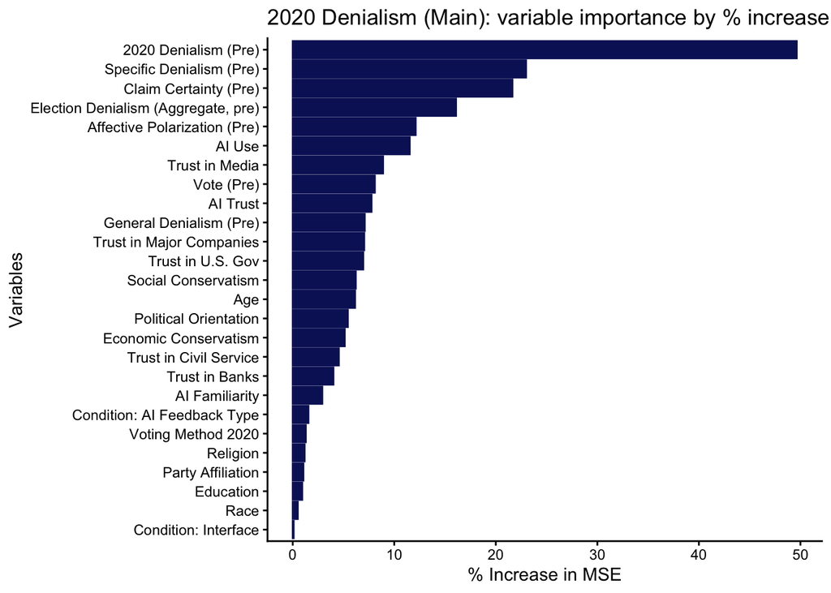

```r
rf_model_er0 <- randomForest(
  formula = ER0Norm_Post ~ ConditionFeedback + ConditionChat +
    ER0Norm_Pre_center + ERNorm_Pre_center + ER1_Pre_center + ER2_Pre_center + Sureness_Pre_center + AffPol_Pre + Race + Age + GenderClean + Education + religion + DemRep_C.text + EconomicConservatism + SocialConservatism + VoteMethod.text + AffPol_Pre + PartyAffil.text + PartyReg.text + VoteFor2020.clean + VoteMethod.text + Vote_1 + InstTrust_USGov + InstTrust_CivilService + InstTrust_Media + InstTrust_Banks + InstTrust_MajorCompanies + genai_trust + genai_fam_1 + genai_use_1,
  data = df_consp_clean,
  importance = TRUE,
  na.action = na.roughfix
)
importance_df_er0 <- as.data.frame(importance(rf_model_er0))
importance_df_er0$Variable <- rownames(importance_df_er0)
importance_df_er0$Variable <- clean_rf_var(importance_df_er0$Variable, rf_label_map)
importance_df_er0 <- importance_df_er0[order(importance_df_er0$`%IncMSE`, decreasing = TRUE), ]
fig_rf_er0 <- ggplot(importance_df_er0 %>% filter(`%IncMSE` > 0), aes(x = reorder(Variable, `%IncMSE`), y = `%IncMSE`)) +
  geom_bar(stat = "identity", fill = "#0B1B66", color = "#0B1B66") +
  coord_flip() +
  labs(
    title = "2020 Denialism (Main): variable importance by % increase in MSE",
    x = "Variables",
    y = "% Increase in MSE"
  ) +
  theme_classic()
fig_rf_er0
```

```r
ggsave("figures/supplement/fig-rf-importance-2020denialism.png", fig_rf_er0, width = 8, height = 5, dpi = 600, create.dir = TRUE)

# Claim Certainty
cat("Fitting Random Forest for Outcome: Sureness_Post_1
")
```

```
## Fitting Random Forest for Outcome: Sureness_Post_1
```

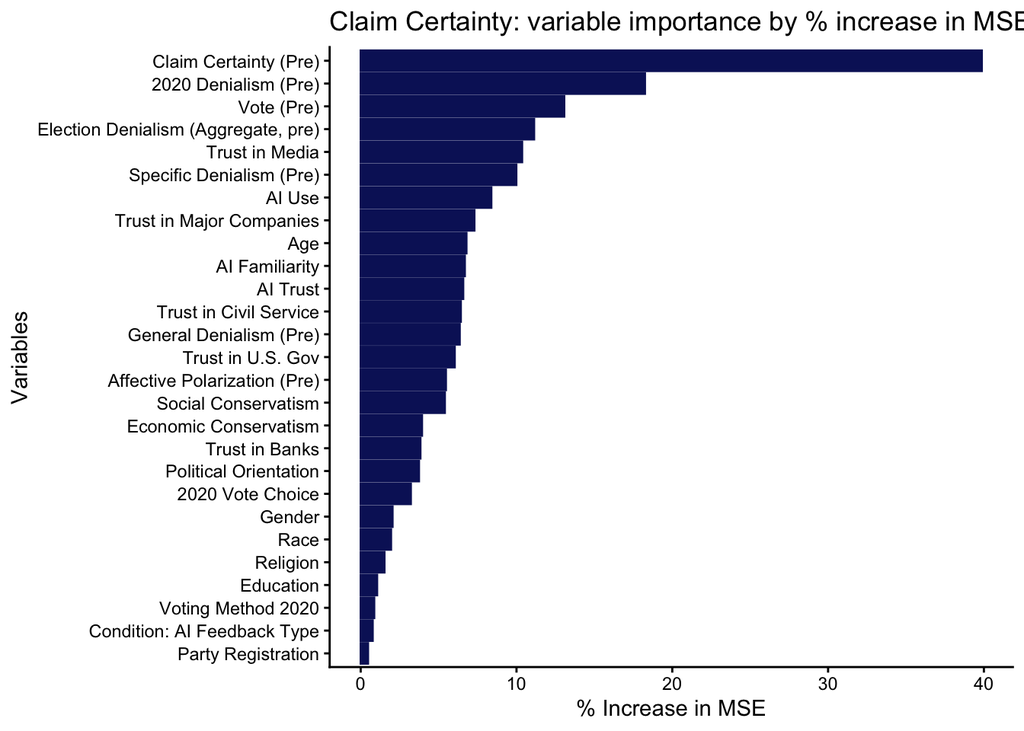

```r
rf_model_sure <- randomForest(
  formula = Sureness_Post_1 ~ ConditionFeedback + ConditionChat +
    ER0Norm_Pre_center + ERNorm_Pre_center + ER1_Pre_center + ER2_Pre_center + Sureness_Pre_center + AffPol_Pre + Race + Age + GenderClean + Education + religion + DemRep_C.text + EconomicConservatism + SocialConservatism + VoteMethod.text + AffPol_Pre + PartyAffil.text + PartyReg.text + VoteFor2020.clean + VoteMethod.text + Vote_1 + InstTrust_USGov + InstTrust_CivilService + InstTrust_Media + InstTrust_Banks + InstTrust_MajorCompanies + genai_trust + genai_fam_1 + genai_use_1,
  data = df_consp_clean,
  importance = TRUE,
  na.action = na.roughfix
)
importance_df_sure <- as.data.frame(importance(rf_model_sure))
importance_df_sure$Variable <- rownames(importance_df_sure)
importance_df_sure$Variable <- clean_rf_var(importance_df_sure$Variable, rf_label_map)
importance_df_sure <- importance_df_sure[order(importance_df_sure$`%IncMSE`, decreasing = TRUE), ]
fig_rf_sure <- ggplot(importance_df_sure %>% filter(`%IncMSE` > 0), aes(x = reorder(Variable, `%IncMSE`), y = `%IncMSE`)) +
  geom_bar(stat = "identity", fill = "#0B1B66", color = "#0B1B66") +
  coord_flip() +
  labs(
    title = "Claim Certainty: variable importance by % increase in MSE",
    x = "Variables",
    y = "% Increase in MSE"
  ) +
  theme_classic()
fig_rf_sure
```

```r
# General Denialism
cat("Fitting Random Forest for Outcome: ER1_Post
")
```

```
## Fitting Random Forest for Outcome: ER1_Post
```

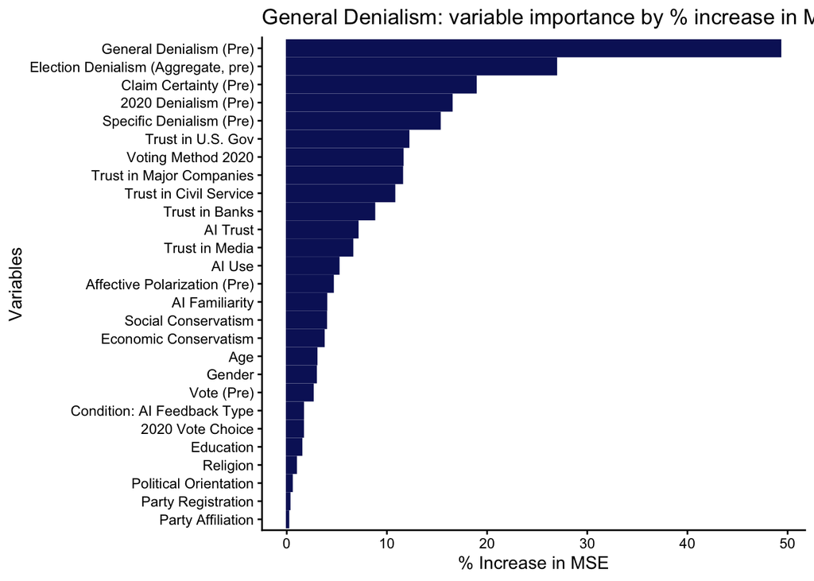

```r
rf_model_er1 <- randomForest(
  formula = ER1_Post ~ ConditionFeedback + ConditionChat +
    ER0Norm_Pre_center + ERNorm_Pre_center + ER1_Pre_center + ER2_Pre_center + Sureness_Pre_center + AffPol_Pre + Race + Age + GenderClean + Education + religion + DemRep_C.text + EconomicConservatism + SocialConservatism + VoteMethod.text + AffPol_Pre + PartyAffil.text + PartyReg.text + VoteFor2020.clean + VoteMethod.text + Vote_1 + InstTrust_USGov + InstTrust_CivilService + InstTrust_Media + InstTrust_Banks + InstTrust_MajorCompanies + genai_trust + genai_fam_1 + genai_use_1,
  data = df_consp_clean,
  importance = TRUE,
  na.action = na.roughfix
)
importance_df_er1 <- as.data.frame(importance(rf_model_er1))
importance_df_er1$Variable <- rownames(importance_df_er1)
importance_df_er1$Variable <- clean_rf_var(importance_df_er1$Variable, rf_label_map)
importance_df_er1 <- importance_df_er1[order(importance_df_er1$`%IncMSE`, decreasing = TRUE), ]
fig_rf_er1 <- ggplot(importance_df_er1 %>% filter(`%IncMSE` > 0), aes(x = reorder(Variable, `%IncMSE`), y = `%IncMSE`)) +
  geom_bar(stat = "identity", fill = "#0B1B66", color = "#0B1B66") +
  coord_flip() +
  labs(
    title = "General Denialism: variable importance by % increase in MSE",
    x = "Variables",
    y = "% Increase in MSE"
  ) +
  theme_classic()
fig_rf_er1
```

```r
# Specific Denialism
cat("Fitting Random Forest for Outcome: ER2_Post
")
```

```
## Fitting Random Forest for Outcome: ER2_Post
```

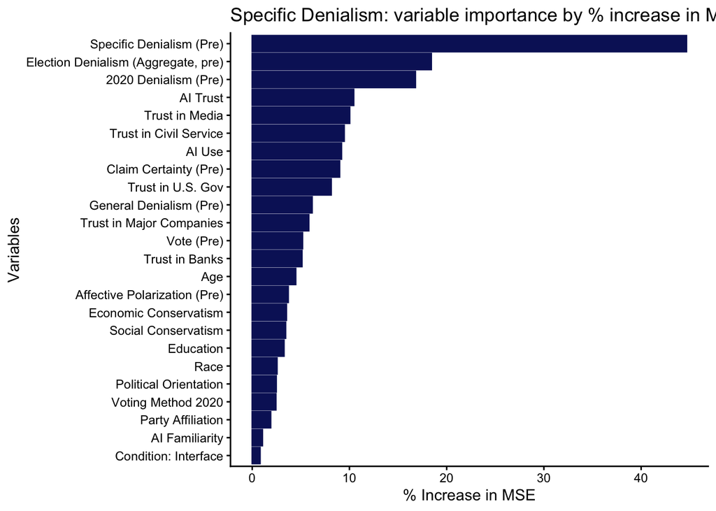

```r
rf_model_er2 <- randomForest(
  formula = ER2_Post ~ ConditionFeedback + ConditionChat +
    ER0Norm_Pre_center + ERNorm_Pre_center + ER1_Pre_center + ER2_Pre_center + Sureness_Pre_center + AffPol_Pre + Race + Age + GenderClean + Education + religion + DemRep_C.text + EconomicConservatism + SocialConservatism + VoteMethod.text + AffPol_Pre + PartyAffil.text + PartyReg.text + VoteFor2020.clean + VoteMethod.text + Vote_1 + InstTrust_USGov + InstTrust_CivilService + InstTrust_Media + InstTrust_Banks + InstTrust_MajorCompanies + genai_trust + genai_fam_1 + genai_use_1,
  data = df_consp_clean,
  importance = TRUE,
  na.action = na.roughfix
)
importance_df_er2 <- as.data.frame(importance(rf_model_er2))
importance_df_er2$Variable <- rownames(importance_df_er2)
importance_df_er2$Variable <- clean_rf_var(importance_df_er2$Variable, rf_label_map)
importance_df_er2 <- importance_df_er2[order(importance_df_er2$`%IncMSE`, decreasing = TRUE), ]
fig_rf_er2 <- ggplot(importance_df_er2 %>% filter(`%IncMSE` > 0), aes(x = reorder(Variable, `%IncMSE`), y = `%IncMSE`)) +
  geom_bar(stat = "identity", fill = "#0B1B66", color = "#0B1B66") +
  coord_flip() +
  labs(
    title = "Specific Denialism: variable importance by % increase in MSE",
    x = "Variables",
    y = "% Increase in MSE"
  ) +
  theme_classic()
fig_rf_er2
```

```r
# 2020 Denialism (Aggregate)
cat("Fitting Random Forest for Outcome: ER2020_Post
")
```

```
## Fitting Random Forest for Outcome: ER2020_Post
```

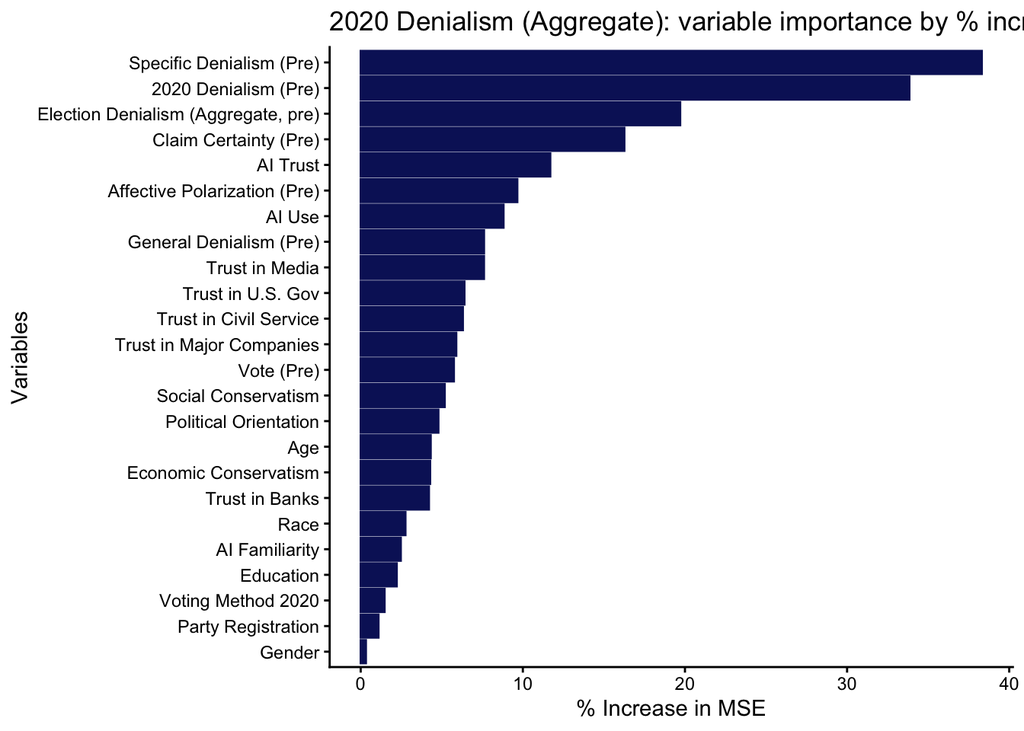

```r
rf_model_er2020 <- randomForest(
  formula = ER2020_Post ~ ConditionFeedback + ConditionChat +
    ER0Norm_Pre_center + ERNorm_Pre_center + ER1_Pre_center + ER2_Pre_center + Sureness_Pre_center + AffPol_Pre + Race + Age + GenderClean + Education + religion + DemRep_C.text + EconomicConservatism + SocialConservatism + VoteMethod.text + AffPol_Pre + PartyAffil.text + PartyReg.text + VoteFor2020.clean + VoteMethod.text + Vote_1 + InstTrust_USGov + InstTrust_CivilService + InstTrust_Media + InstTrust_Banks + InstTrust_MajorCompanies + genai_trust + genai_fam_1 + genai_use_1,
  data = df_consp_clean,
  importance = TRUE,
  na.action = na.roughfix
)
importance_df_er2020 <- as.data.frame(importance(rf_model_er2020))
importance_df_er2020$Variable <- rownames(importance_df_er2020)
importance_df_er2020$Variable <- clean_rf_var(importance_df_er2020$Variable, rf_label_map)
importance_df_er2020 <- importance_df_er2020[order(importance_df_er2020$`%IncMSE`, decreasing = TRUE), ]
fig_rf_er2020 <- ggplot(importance_df_er2020 %>% filter(`%IncMSE` > 0), aes(x = reorder(Variable, `%IncMSE`), y = `%IncMSE`)) +
  geom_bar(stat = "identity", fill = "#0B1B66", color = "#0B1B66") +
  coord_flip() +
  labs(
    title = "2020 Denialism (Aggregate): variable importance by % increase in MSE",
    x = "Variables",
    y = "% Increase in MSE"
  ) +
  theme_classic()
fig_rf_er2020
```

```r
# 2024 Denialism
cat("Fitting Random Forest for Outcome: ER2024_Post
")
```

```
## Fitting Random Forest for Outcome: ER2024_Post
```

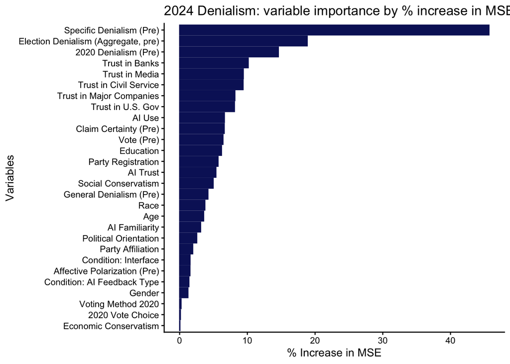

```r
rf_model_er2024 <- randomForest(
  formula = ER2024_Post ~ ConditionFeedback + ConditionChat +
    ER0Norm_Pre_center + ERNorm_Pre_center + ER1_Pre_center + ER2_Pre_center + Sureness_Pre_center + AffPol_Pre + Race + Age + GenderClean + Education + religion + DemRep_C.text + EconomicConservatism + SocialConservatism + VoteMethod.text + AffPol_Pre + PartyAffil.text + PartyReg.text + VoteFor2020.clean + VoteMethod.text + Vote_1 + InstTrust_USGov + InstTrust_CivilService + InstTrust_Media + InstTrust_Banks + InstTrust_MajorCompanies + genai_trust + genai_fam_1 + genai_use_1,
  data = df_consp_clean,
  importance = TRUE,
  na.action = na.roughfix
)
importance_df_er2024 <- as.data.frame(importance(rf_model_er2024))
importance_df_er2024$Variable <- rownames(importance_df_er2024)
importance_df_er2024$Variable <- clean_rf_var(importance_df_er2024$Variable, rf_label_map)
importance_df_er2024 <- importance_df_er2024[order(importance_df_er2024$`%IncMSE`, decreasing = TRUE), ]
fig_rf_er2024 <- ggplot(importance_df_er2024 %>% filter(`%IncMSE` > 0), aes(x = reorder(Variable, `%IncMSE`), y = `%IncMSE`)) +
  geom_bar(stat = "identity", fill = "#0B1B66", color = "#0B1B66") +
  coord_flip() +
  labs(
    title = "2024 Denialism: variable importance by % increase in MSE",
    x = "Variables",
    y = "% Increase in MSE"
  ) +
  theme_classic()
fig_rf_er2024
```

```r
# Election Denialism (Aggregate)
cat("Fitting Random Forest for Outcome: ER_Post
")
```

```
## Fitting Random Forest for Outcome: ER_Post
```

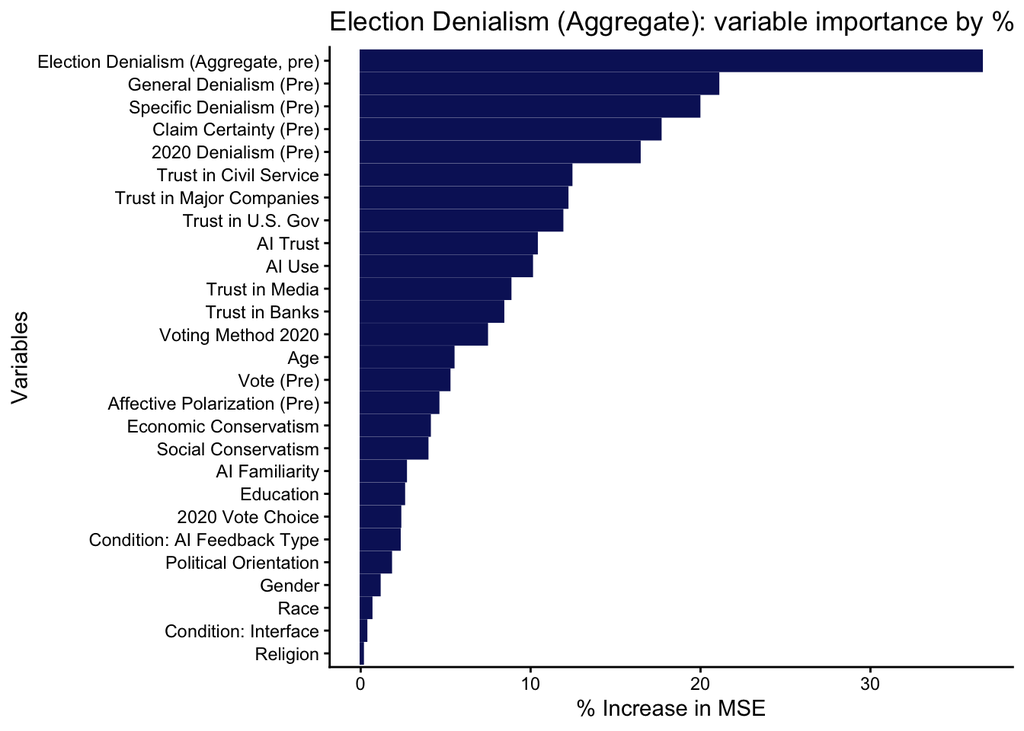

```r
rf_model_eragg <- randomForest(
  formula = ER_Post ~ ConditionFeedback + ConditionChat +
    ER0Norm_Pre_center + ERNorm_Pre_center + ER1_Pre_center + ER2_Pre_center + Sureness_Pre_center + AffPol_Pre + Race + Age + GenderClean + Education + religion + DemRep_C.text + EconomicConservatism + SocialConservatism + VoteMethod.text + AffPol_Pre + PartyAffil.text + PartyReg.text + VoteFor2020.clean + VoteMethod.text + Vote_1 + InstTrust_USGov + InstTrust_CivilService + InstTrust_Media + InstTrust_Banks + InstTrust_MajorCompanies + genai_trust + genai_fam_1 + genai_use_1,
  data = df_consp_clean,
  importance = TRUE,
  na.action = na.roughfix
)
importance_df_eragg <- as.data.frame(importance(rf_model_eragg))
importance_df_eragg$Variable <- rownames(importance_df_eragg)
importance_df_eragg$Variable <- clean_rf_var(importance_df_eragg$Variable, rf_label_map)
importance_df_eragg <- importance_df_eragg[order(importance_df_eragg$`%IncMSE`, decreasing = TRUE), ]
fig_rf_eragg <- ggplot(importance_df_eragg %>% filter(`%IncMSE` > 0), aes(x = reorder(Variable, `%IncMSE`), y = `%IncMSE`)) +
  geom_bar(stat = "identity", fill = "#0B1B66", color = "#0B1B66") +
  coord_flip() +
  labs(
    title = "Election Denialism (Aggregate): variable importance by % increase in MSE",
    x = "Variables",
    y = "% Increase in MSE"
  ) +
  theme_classic()
fig_rf_eragg
```

```r
# Affective Polarization
cat("Fitting Random Forest for Outcome: AffPol_Post
")
```

```
## Fitting Random Forest for Outcome: AffPol_Post
```

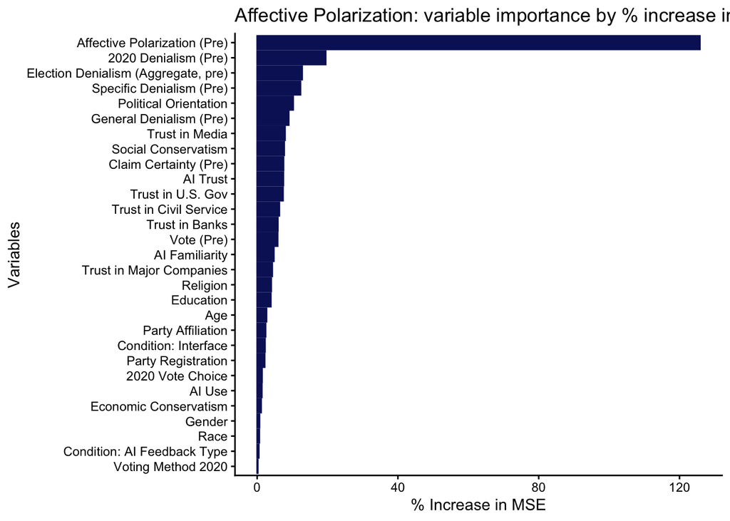

```r
rf_model_ap <- randomForest(
  formula = AffPol_Post ~ ConditionFeedback + ConditionChat +
    ER0Norm_Pre_center + ERNorm_Pre_center + ER1_Pre_center + ER2_Pre_center + Sureness_Pre_center + AffPol_Pre + Race + Age + GenderClean + Education + religion + DemRep_C.text + EconomicConservatism + SocialConservatism + VoteMethod.text + AffPol_Pre + PartyAffil.text + PartyReg.text + VoteFor2020.clean + VoteMethod.text + Vote_1 + InstTrust_USGov + InstTrust_CivilService + InstTrust_Media + InstTrust_Banks + InstTrust_MajorCompanies + genai_trust + genai_fam_1 + genai_use_1,
  data = df_consp_clean,
  importance = TRUE,
  na.action = na.roughfix
)
importance_df_ap <- as.data.frame(importance(rf_model_ap))
importance_df_ap$Variable <- rownames(importance_df_ap)
importance_df_ap$Variable <- clean_rf_var(importance_df_ap$Variable, rf_label_map)
importance_df_ap <- importance_df_ap[order(importance_df_ap$`%IncMSE`, decreasing = TRUE), ]
fig_rf_ap <- ggplot(importance_df_ap %>% filter(`%IncMSE` > 0), aes(x = reorder(Variable, `%IncMSE`), y = `%IncMSE`)) +
  geom_bar(stat = "identity", fill = "#0B1B66", color = "#0B1B66") +
  coord_flip() +
  labs(
    title = "Affective Polarization: variable importance by % increase in MSE",
    x = "Variables",
    y = "% Increase in MSE"
  ) +
  theme_classic()
fig_rf_ap
```